# Pak Choi Diversity Analyses

Eddy Dowle

2025-07-09

## Pak choi

Diversity analyses, and summary plots

```r
#setwd("C:/Users/hrlexd/Dropbox/PlantAndFood (1)/B4BI/Pakchoi/")

#data<-read_excel('C:/Users/hrlexd/Dropbox/PlantAndFood (1)/B4BI/Pakchoi/Copy of Pak choi pollinators Heather analysis Brad update.xlsx',sheet='DataSheet')
#switching to fixed up dataset
data<-read_excel('C:/Users/hrlexd/Dropbox/PlantAndFood (1)/B4BI/Pakchoi/Copy of Pak choi pollinators raw visits Brad correctedupdatedEddy.xlsx',sheet='Pak choi raw visits')

#filter out things that are 2018 in Boundary age column
data<-data %>% filter(`Boundary age`!=2018)


brads_col_2<-read_excel('C:/Users/hrlexd/Dropbox/PlantAndFood (1)/B4BI/Pakchoi/Eddy Pie chart short.xlsx',sheet='Colours')
#tidy up some names etc
data$Boundary_descriptor<-gsub('one year old','One year old',data$Boundary_descriptor)
data$Boundary_descriptor<-gsub('two year old','Two year old',data$Boundary_descriptor)
data$Boundary_descriptor<-gsub('three year old','Three year old',data$Boundary_descriptor)
data$Boundary_descriptor<-gsub('Bare_fence','Bare fence',data$Boundary_descriptor)
data$Boundary_descriptor<-gsub('Control_farm','Control farm',data$Boundary_descriptor)


#summarising counts to clean up dataset etc for box plots
data_box<-data %>% select(-`Broad Insect category`,-Origin,-`Boundary age`,-`Sum of Insect_Count`,-`Flower count`) %>% group_by(`Farm type`,Farm_name,Season,Boundary_descriptor,`Insect key number`,`New Inseck key name`) %>% summarise(`Sum of Insects/100 flowers`=sum(`Sum of Insects/100 flowers`) )
```

```
## 'Boundary_descriptor', 'Insect key number'. You can override using the
```

```r
#counts per for below graph of abundance estimate per site
data_per<-data_box%>% mutate(Boundary_year=paste0(Boundary_descriptor,'_',Season)) %>% select(-`Insect key number`,-Boundary_descriptor,-Season) %>% group_by(`Farm type`,Farm_name,Boundary_year,`New Inseck key name`) %>% summarise(total_count=sum(`Sum of Insects/100 flowers`)) %>% ungroup() %>% group_by(`Farm type`,Farm_name,Boundary_year) %>% mutate(per=100*total_count/sum(total_count)) %>% ungroup()
```

```
## number`
## You can override using the `.groups` argument.
```

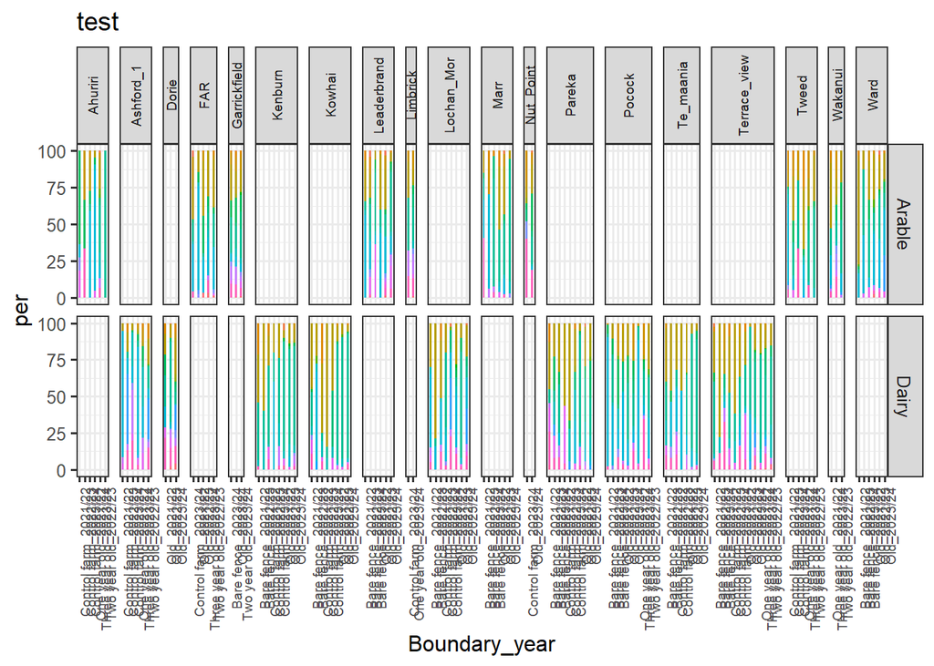

```r
data_per %>%   ggplot(aes(x = Boundary_year, y = per, fill = `New Inseck key name`)) +
  geom_bar(position='stack',stat='identity',width=0.4) +
  facet_grid(`Farm type`~Farm_name, scales = "free", space = "free") +
  theme_bw(base_size = 12) +
  theme(strip.text.x = element_text(angle = 90,size=7),axis.text.x = element_text(angle = 90,size=7,hjust=1))+
  ggtitle(paste('test'))+
 theme(legend.position="none")
```

```r
mydf<- data_box %>% mutate(Boundary_year=paste0(Boundary_descriptor,'_',Season))

#setting up for brads colour scheme
#relevel to brads order
brads_col_2$`New Inseck key name` <- factor(brads_col_2$`New Inseck key name`, levels=brads_col_2$`New Inseck key name`[order(brads_col_2$`Insect key number`)], ordered=TRUE)

#relevel to brads order
mydf$`New Inseck key name` <- forcats::fct_relevel(mydf$`New Inseck key name` ,levels(brads_col_2$`New Inseck key name`))
```

## Diversity statistics

Bar charts to view diversity over different groups

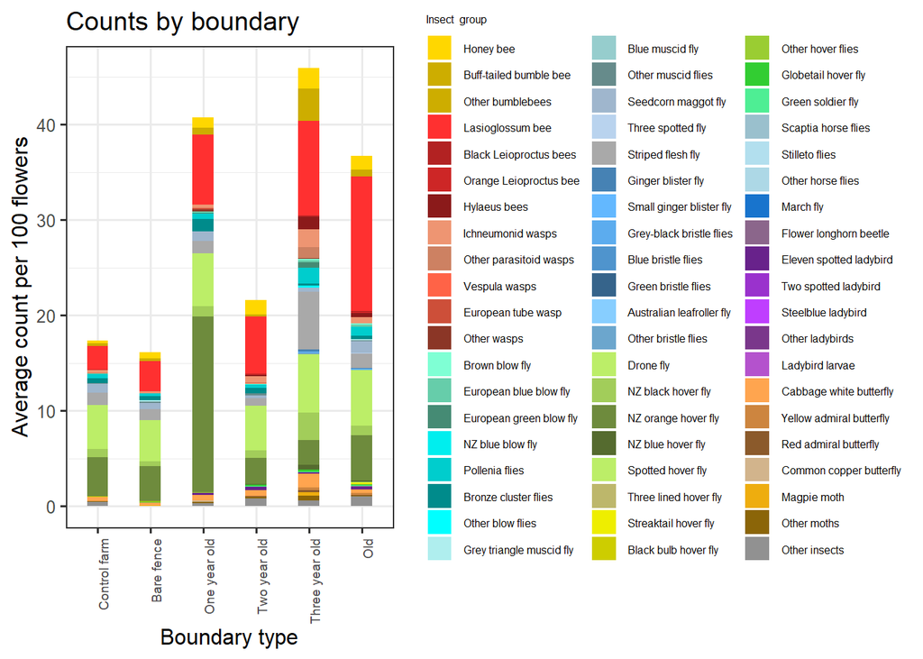

```r
##bar chart raw abundances .....
#cant just be raw count
#needs to be average by sampling number

mydf_byboundary_farm_count<-mydf %>% select(-`Insect key number`,-`Farm type`,-Boundary_year) %>% mutate(unique_ob=paste(Boundary_descriptor,Farm_name,Season)) %>% select(-Farm_name,-Season) %>% group_by(Boundary_descriptor,`New Inseck key name`) %>% summarise(count_farms_perobs=sum(`Sum of Insects/100 flowers`)/n_distinct(unique_ob))
mydf_byboundary_farm_count$Boundary_descriptor <- factor(mydf_byboundary_farm_count$Boundary_descriptor,levels=c('Control farm','Bare fence','One year old','Two year old','Three year old','Old'),ordered = T)

mydf_byboundary_farm_count %>%   ggplot(aes(x = Boundary_descriptor, y = count_farms_perobs, fill = `New Inseck key name`)) +
  geom_bar(position='stack',stat='identity',width=0.4) +
  # facet_grid(`Farm type`~Farm_name, scales = "free", space = "free") +
  theme_bw(base_size = 12) +
  theme(strip.text.x = element_text(angle = 90,size=7),axis.text.x = element_text(angle = 90,size=7,hjust=1))+
  scale_fill_manual(values=with(brads_col_2,setNames(Brad_colours,`New Inseck key name`)))+
  ggtitle(paste('Counts by boundary'))+ylab('Average count per 100 flowers')+xlab('Boundary type')+
  labs(fill = "Insect  group")+
  theme(
    legend.text = element_text(size = 6),
    legend.title = element_text(size = 6),
    legend.key.size = unit(1,"line"))
```

```r
#bar chart relative abundances % bare fence, control year 1, year 2 year3 and old
mydf_byboundary<-mydf%>% select(-`Insect key number`,-Season,-`Farm type`,-Farm_name,-Boundary_year) %>% group_by(Boundary_descriptor,`New Inseck key name`) %>% summarise(total_count=sum(`Sum of Insects/100 flowers`)) %>% ungroup() %>% group_by(Boundary_descriptor) %>% mutate(per=100*total_count/sum(total_count)) %>% ungroup()
```

```
## key number`
```

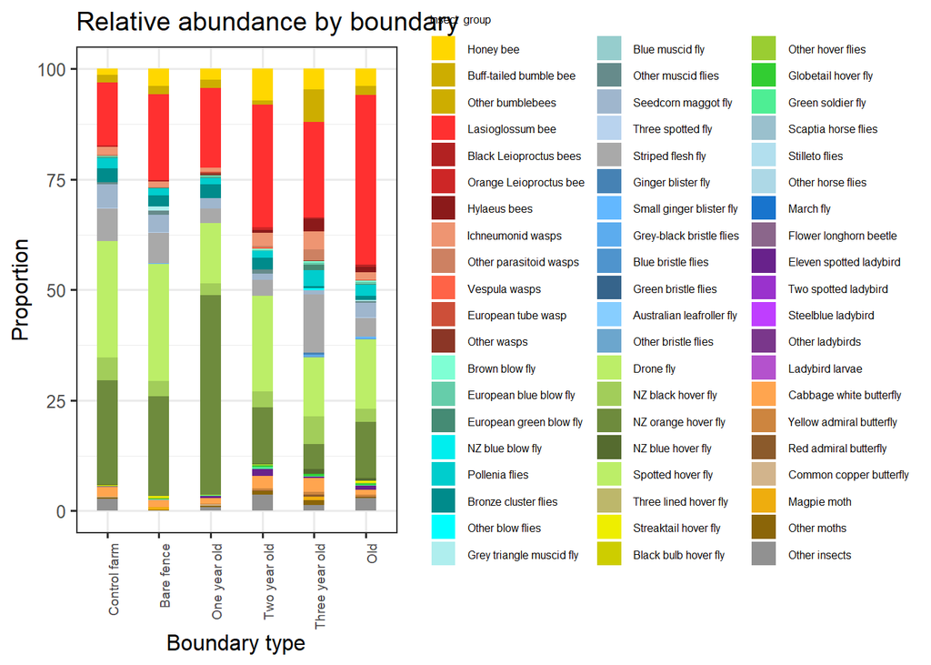

```r
#recolour and tidy
mydf_byboundary$Boundary_descriptor <- factor(mydf_byboundary$Boundary_descriptor,levels=c('Control farm','Bare fence','One year old','Two year old','Three year old','Old'),ordered = T)

mydf_byboundary %>%   ggplot(aes(x = Boundary_descriptor, y = per, fill = `New Inseck key name`)) +
  geom_bar(position='stack',stat='identity',width=0.4) +
  # facet_grid(`Farm type`~Farm_name, scales = "free", space = "free") +
  theme_bw(base_size = 12) +
  theme(strip.text.x = element_text(angle = 90,size=7),axis.text.x = element_text(angle = 90,size=7,hjust=1))+
  scale_fill_manual(values=with(brads_col_2,setNames(Brad_colours,`New Inseck key name`)))+
  ggtitle(paste('Relative abundance by boundary'))+ylab('Proportion')+xlab('Boundary type')+
  labs(fill = "Insect  group")+
  theme(
    legend.text = element_text(size = 6),
    legend.title = element_text(size = 6),
    legend.key.size = unit(1,"line"))
```

## Bar charts split by season

Alpha diversity (below) suggests there might be a role of season, so just splitting that out here

```r
#Adding in season
##bar chart raw abundances .....
#cant just be raw count
#needs to be average by sampling number

mydf_byboundary_farm_count_yr<-mydf %>% select(-`Insect key number`,-`Farm type`,-Boundary_descriptor,-Season) %>% mutate(unique_ob=paste(Boundary_year,Farm_name)) %>% select(-Farm_name) %>% group_by(Boundary_year,`New Inseck key name`) %>% summarise(count_farms_perobs=sum(`Sum of Insects/100 flowers`)/n_distinct(unique_ob))
```

```
## `Boundary_descriptor`, `Insect key number`
```

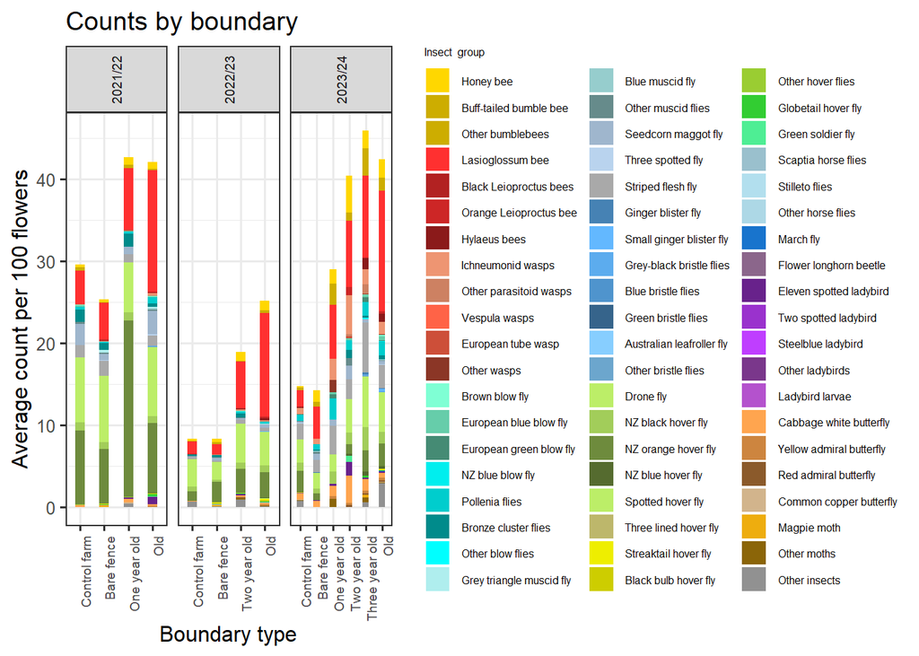

```r
mydf_byboundary_farm_count_yr<-mydf_byboundary_farm_count_yr %>% separate_wider_delim(Boundary_year,'_',names=c("Boundary_descriptor","Season"))

mydf_byboundary_farm_count_yr$Boundary_descriptor <- factor(mydf_byboundary_farm_count_yr$Boundary_descriptor,levels=c('Control farm','Bare fence','One year old','Two year old','Three year old','Old'),ordered = T)

mydf_byboundary_farm_count_yr %>%   ggplot(aes(x = Boundary_descriptor, y = count_farms_perobs, fill = `New Inseck key name`)) +
  geom_bar(position='stack',stat='identity',width=0.4) +
  facet_grid(~Season, scales = "free") +
  theme_bw(base_size = 12) +
  theme(strip.text.x = element_text(angle = 90,size=7),axis.text.x = element_text(angle = 90,size=7,hjust=1))+
  scale_fill_manual(values=with(brads_col_2,setNames(Brad_colours,`New Inseck key name`)))+
  ggtitle(paste('Counts by boundary'))+ylab('Average count per 100 flowers')+xlab('Boundary type')+
  labs(fill = "Insect  group")+
  theme(
    legend.text = element_text(size = 6),
    legend.title = element_text(size = 6),
    legend.key.size = unit(1,"line"))
```

```r
#adding in season
#bar chart relative abundances % bare fence, control year 1, year 2 year3 and old

mydf_byboundary_yr<-mydf%>% select(-`Insect key number`,-Season,-`Farm type`,-Farm_name,-Boundary_descriptor) %>% group_by(Boundary_year,`New Inseck key name`) %>% summarise(total_count=sum(`Sum of Insects/100 flowers`)) %>% ungroup() %>% group_by(Boundary_year) %>% mutate(per=100*total_count/sum(total_count)) %>% ungroup()
```

```
## `Boundary_descriptor`, `Insect key number`
```

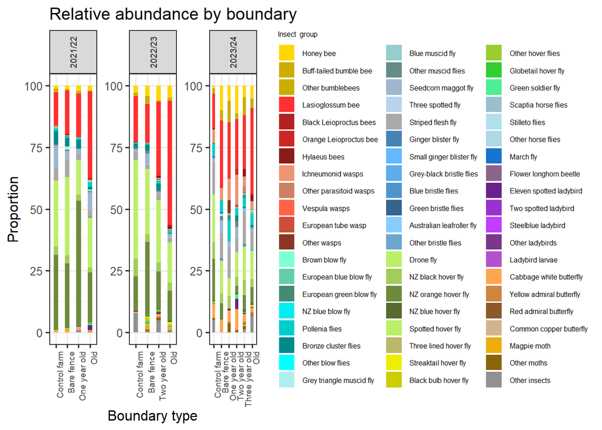

```r
mydf_byboundary_yr<-mydf_byboundary_yr %>% separate_wider_delim(Boundary_year,'_',names=c("Boundary_descriptor","Season"))

#recolour and tidy
mydf_byboundary_yr$Boundary_descriptor <- factor(mydf_byboundary_yr$Boundary_descriptor,levels=c('Control farm','Bare fence','One year old','Two year old','Three year old','Old'),ordered = T)

mydf_byboundary_yr %>%   ggplot(aes(x = Boundary_descriptor, y = per, fill = `New Inseck key name`)) +
  geom_bar(position='stack',stat='identity',width=0.4) +
  facet_wrap(~Season,scales="free") +
  theme_bw(base_size = 12) +
  theme(strip.text.x = element_text(angle = 90,size=7),axis.text.x = element_text(angle = 90,size=7,hjust=1))+
  scale_fill_manual(values=with(brads_col_2,setNames(Brad_colours,`New Inseck key name`)))+
  ggtitle(paste('Relative abundance by boundary'))+ylab('Proportion')+xlab('Boundary type')+
  labs(fill = "Insect  group")+
  theme(
    legend.text = element_text(size = 6),
    legend.title = element_text(size = 6),
    legend.key.size = unit(1,"line"))
```

## Alpha diversity

Species count using species count Im switching to raw counts here, one issue is that flower number varies so need to check the relationship between diversity and flower number

```r
#Alpha diversity
#one matrix of the counts
#one metadata file

#switching to raw counts
#data<-read_excel('C:/Users/hrlexd/Dropbox/PlantAndFood (1)/B4BI/Pakchoi/Pak choi pollinators raw visits Brad updatedxlsx.xlsx',sheet='Pak choi raw visits')
#switching to fixed up dataset
data<-read_excel('C:/Users/hrlexd/Dropbox/PlantAndFood (1)/B4BI/Pakchoi/Copy of Pak choi pollinators raw visits Brad correctedupdatedEddy.xlsx',sheet='Pak choi raw visits')

#filter out things that are 2018 in Boundary age column
data<-data %>% filter(`Boundary age`!=2018)

brads_col_2<-read_excel('C:/Users/hrlexd/Dropbox/PlantAndFood (1)/B4BI/Pakchoi/Eddy Pie chart short.xlsx',sheet='Colours')
#tidy up some names etc
data$Boundary_descriptor<-gsub('one year old','One year old',data$Boundary_descriptor)
data$Boundary_descriptor<-gsub('two year old','Two year old',data$Boundary_descriptor)
data$Boundary_descriptor<-gsub('three year old','Three year old',data$Boundary_descriptor)
data$Boundary_descriptor<-gsub('Bare_fence','Bare fence',data$Boundary_descriptor)
data$Boundary_descriptor<-gsub('Control_farm','Control farm',data$Boundary_descriptor)

unique(data$Boundary_descriptor)
```

```
## [1] "Control farm"   "One year old"   "Two year old"   "Three year old"
## [5] "Old"            "Bare fence"
```

```r
colnames(data)
```

```
##  [1] "Farm type"                  "Farm_name"
##  [3] "Season"                     "Boundary_descriptor"
##  [5] "Boundary age"               "Insect key number"
##  [7] "New Inseck key name"        "Sum of Insects/100 flowers"
##  [9] "Broad Insect category"      "Origin"
## [11] "Sum of Insect_Count"        "Flower count"
```

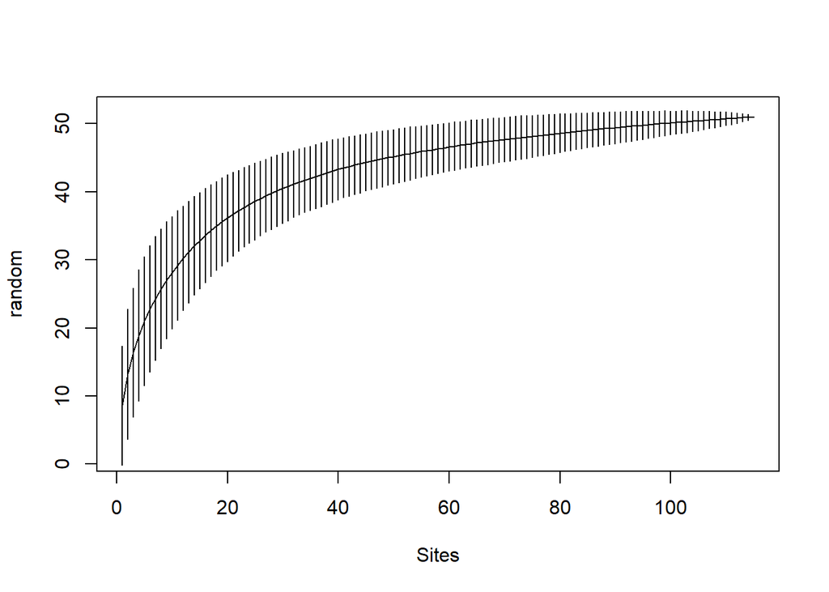

```r
#summarising counts to clean up dataset etc
mydf<-data %>% select(-`Broad Insect category`,-Origin,-`Boundary age`,-`Sum of Insects/100 flowers`)

mydf<-mydf %>% mutate(unique_sample=paste(Boundary_descriptor,Farm_name,Season))

counts<-mydf %>% ungroup() %>% select(unique_sample,`New Inseck key name`,`Sum of Insect_Count`)

#transform wide
counts_wide<-counts %>% pivot_wider(names_from=`New Inseck key name`,values_from = `Sum of Insect_Count`)
counts_wide<-counts_wide %>% remove_rownames %>% column_to_rownames(var="unique_sample")

#species accumulation curve
speccurve<-specaccum(counts_wide,method='random',permutations=1000)
plot(speccurve)
```

```r
#count species per property
sppr <- specnumber(counts_wide)
head(sppr)
```

```
##   Control farm Ahuriri 2021/22   One year old Ahuriri 2021/22
##                              4                              5
##   Control farm Ahuriri 2022/23   Two year old Ahuriri 2022/23
##                              3                              1
##   Control farm Ahuriri 2023/24 Three year old Ahuriri 2023/24
##                              5                             15
```

```r
#anova against variables, does mean species richness vary among treatments?
#meta_data<-mydf %>% ungroup() %>% select(unique_sample,Boundary_descriptor,Season,Farm_name,`Farm type`,`Flower count`) %>% unique()
#write.csv(meta_data,'C:/Users/hrlexd/Dropbox/PlantAndFood (1)/B4BI/Pakchoi/Meta_data_pakchoi.csv',row.names=F)

meta_data<-read_excel('C:/Users/hrlexd/Dropbox/PlantAndFood (1)/B4BI/Pakchoi/Copy of Meta_data_pakchoiBH.xlsx',sheet='Meta_data_pakchoi')
rownames(meta_data) <- meta_data$unique_sample
sppr_aov <-aov(sppr ~ Boundary_descriptor, data = meta_data)
summary(sppr_aov)
```

```
##                      Df Sum Sq Mean Sq F value   Pr(>F)
## Boundary_descriptor   5  653.1  130.62   9.325 2.04e-07 ***
## Residuals           109 1526.7   14.01
## ---
## Signif. codes:  0 '***' 0.001 '**' 0.01 '*' 0.05 '.' 0.1 ' ' 1
```

```r
#impact of season and boundary
sppr_aov <-aov(sppr ~ Boundary_descriptor+Season, data = meta_data)
summary(sppr_aov)
```

```
##                      Df Sum Sq Mean Sq F value   Pr(>F)
## Boundary_descriptor   5  653.1  130.62  10.651 2.54e-08 ***
## Season                2  214.5  107.25   8.745 0.000304 ***
## Residuals           107 1312.2   12.26
## ---
## Signif. codes:  0 '***' 0.001 '**' 0.01 '*' 0.05 '.' 0.1 ' ' 1
```

```r
#impact of season and boundary and farm type
sppr_aov <-aov(sppr ~ Boundary_descriptor+Season+`Farm type`, data = meta_data)
summary(sppr_aov)
```

```
##                      Df Sum Sq Mean Sq F value   Pr(>F)
## Boundary_descriptor   5  653.1  130.62  10.552 3.06e-08 ***
## Season                2  214.5  107.25   8.664 0.000327 ***
## `Farm type`           1    0.1    0.08   0.006 0.937532
## Residuals           106 1312.1   12.38
## ---
## Signif. codes:  0 '***' 0.001 '**' 0.01 '*' 0.05 '.' 0.1 ' ' 1
```

```r
#impact of flower number (lm as flower count continuous variable)
sppr_aov <-lm(sppr ~ `Flower count`, data = meta_data)
summary(sppr_aov)
```

```
##
## Call:
## lm(formula = sppr ~ `Flower count`, data = meta_data)
##
## Residuals:
##     Min      1Q  Median      3Q     Max
## -7.1980 -2.8111 -0.8595  2.4376 11.2874
##
## Coefficients:
##                Estimate Std. Error t value Pr(>|t|)
## (Intercept)    5.659194   1.089077   5.196 9.11e-07 ***
## `Flower count` 0.012090   0.004088   2.957  0.00378 **
## ---
## Signif. codes:  0 '***' 0.001 '**' 0.01 '*' 0.05 '.' 0.1 ' ' 1
##
## Residual standard error: 4.231 on 113 degrees of freedom
## Multiple R-squared:  0.07182,    Adjusted R-squared:  0.06361
## F-statistic: 8.744 on 1 and 113 DF,  p-value: 0.003782
```

```r
#####################################################
#######eddys ideal world would have this as the model:
#####################################################
#in the ideal world I would like this as it keeps it in the standard anova framework which makes posthoc tests etc easy:
#flower count as a offset
sppr_aov <-aov(sppr ~ Boundary_descriptor + Season + offset(log(`Flower count`)) , data = meta_data)
summary(sppr_aov)
```

```
##                      Df Sum Sq Mean Sq F value  Pr(>F)
## Boundary_descriptor   5  661.7  132.34  11.466 7.1e-09 ***
## Season                2  208.2  104.08   9.018 0.00024 ***
## Residuals           107 1234.9   11.54
## ---
## Signif. codes:  0 '***' 0.001 '**' 0.01 '*' 0.05 '.' 0.1 ' ' 1
```

```r
TukeyHSD(sppr_aov)
```

```
##   Tukey multiple comparisons of means
##     95% family-wise confidence level
##
## Fit: aov(formula = sppr ~ Boundary_descriptor + Season + offset(log(`Flower count`)), data = meta_data)
##
## $Boundary_descriptor
##                                   diff        lwr       upr     p adj
## Control farm-Bare fence     -0.2735721 -2.9101682  2.363024 0.9996595
## Old-Bare fence               4.3470679  1.8516820  6.842454 0.0000260
## One year old-Bare fence      3.0568605 -1.1247061  7.238427 0.2842797
## Three year old-Bare fence    7.0813950  2.8998283 11.262962 0.0000468
## Two year old-Bare fence      3.3775851 -0.5910175  7.346188 0.1425052
## Old-Control farm             4.6206400  2.1755064  7.065773 0.0000041
## One year old-Control farm    3.3304326 -0.8213414  7.482207 0.1921362
## Three year old-Control farm  7.3549671  3.2031931 11.506741 0.0000181
## Two year old-Control farm    3.6511572 -0.2860416  7.588356 0.0854445
## One year old-Old            -1.2902073 -5.3537697  2.773355 0.9402087
## Three year old-Old           2.7343271 -1.3292352  6.797889 0.3764134
## Two year old-Old            -0.9694828 -4.8135491  2.874584 0.9775495
## Three year old-One year old  4.0245345 -1.2452936  9.294363 0.2390218
## Two year old-One year old    0.3207246 -4.7817645  5.423214 0.9999713
## Two year old-Three year old -3.7038099 -8.8062990  1.398679 0.2918611
##
## $Season
##                       diff        lwr       upr     p adj
## 2022/23-2021/22 -0.9071981 -2.7720939 0.9576976 0.4819277
## 2023/24-2021/22  2.0229909  0.1812391 3.8647426 0.0276703
## 2023/24-2022/23  2.9301890  1.1010694 4.7593086 0.0006814
```

```r
#can plot that out
sppr_df <- sppr %>%
  enframe() %>%
  full_join(meta_data, by = c("name" = "unique_sample"))

sppr_df$Boundary_descriptor <- factor(sppr_df$Boundary_descriptor,levels=c('Control farm','Bare fence','One year old','Two year old','Three year old','Old'),ordered = T)

#brad colour scheme (control to old):
col_bound<-c('chocolate','#FDE725FF',"#5DC863FF","#21908CFF",'#3B528BFF',"#440154FF")
col_bound
```

```
## [1] "chocolate" "#FDE725FF" "#5DC863FF" "#21908CFF" "#3B528BFF" "#440154FF"
```

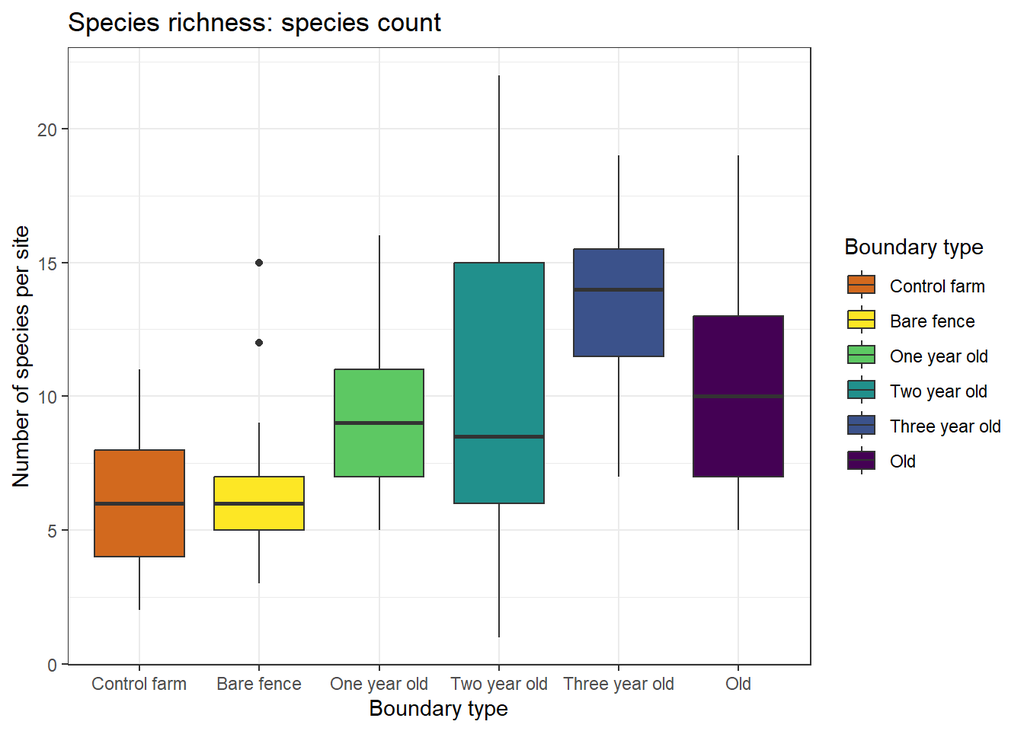

```r
#just boundary
plot_sppr <- ggplot(sppr_df, aes(x = Boundary_descriptor, y = value, fill = Boundary_descriptor)) +
  geom_boxplot() +
  theme_bw()+
  scale_fill_manual(values=col_bound)+
  labs(x = "Boundary type",
       y = "Number of species per site",
       title = "Species richness: species count",
       fill = "Boundary type")
plot_sppr
```

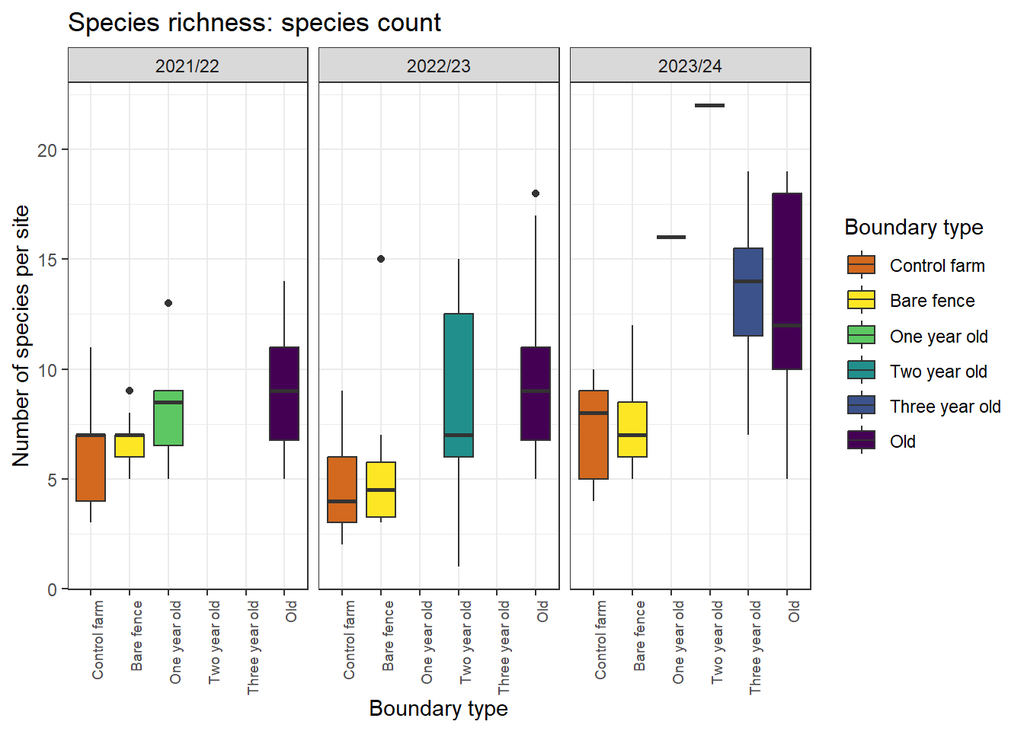

```r
#other significant factor was season
plot_sppr <- ggplot(sppr_df, aes(x = Boundary_descriptor, y = value, fill = Boundary_descriptor)) +
  geom_boxplot() +
facet_wrap(~Season)+
    scale_fill_manual(values=col_bound)+
  theme_bw()+
  labs(x = "Boundary type",
       y = "Number of species per site",
       title = "Species richness: species count",
       fill = "Boundary type")+
  theme(axis.text.x = element_text(angle = 90,size=7,hjust=1))

plot_sppr
```

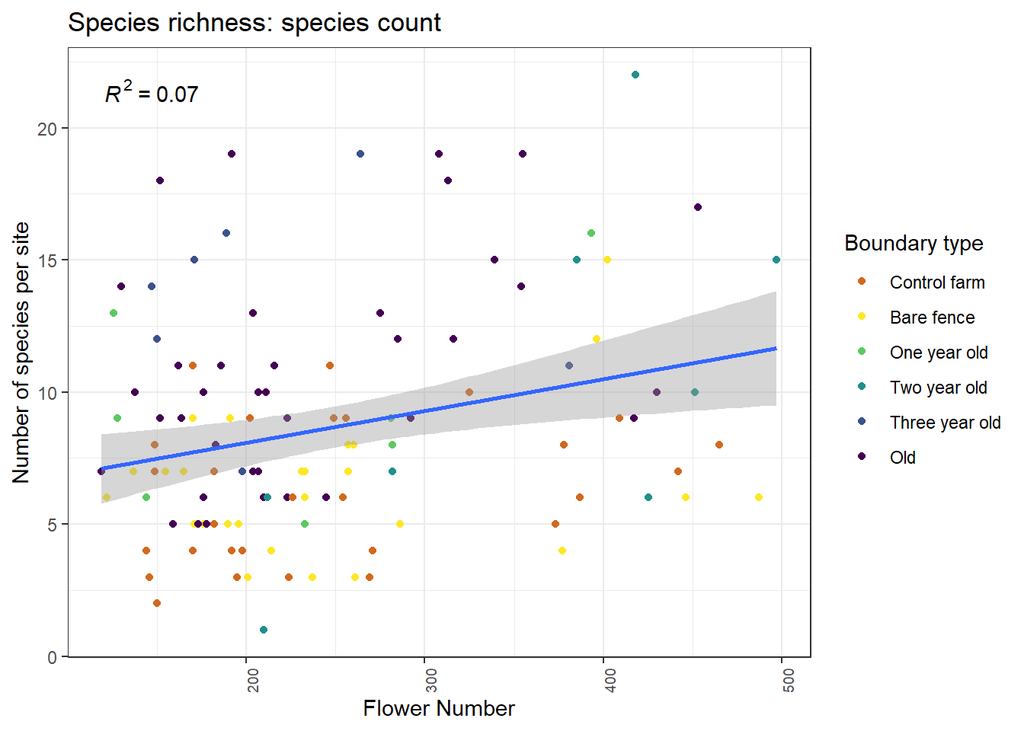

```r
#flower number:
plot_sppr <- ggplot(sppr_df, aes(x = `Flower count`, y = value)) +
  geom_point(aes(colour = Boundary_descriptor)) +
  scale_colour_manual(values=col_bound)+
  stat_poly_line() +
  stat_poly_eq() +
   theme_bw()+
  labs(x = "Flower Number",
       y = "Number of species per site",
       title = "Species richness: species count", colour = "Boundary type")+
  theme(axis.text.x = element_text(angle = 90,size=7,hjust=1))

plot_sppr
```

```r
#an alternative is that given that we are not really interested in season maybe this is best:
#season as a random effect
m1<-lmer(sppr ~ Boundary_descriptor + offset(log(`Flower count`)) + (1|Season), data = meta_data)
summary(m1)
```

```
## Linear mixed model fit by REML. t-tests use Satterthwaite's method [
## lmerModLmerTest]
## Formula: sppr ~ Boundary_descriptor + offset(log(`Flower count`)) + (1 |
##     Season)
##    Data: meta_data
##
## REML criterion at convergence: 596.5
##
## Scaled residuals:
##     Min      1Q  Median      3Q     Max
## -2.4648 -0.6820 -0.1258  0.4609  2.6866
##
## Random effects:
##  Groups   Name        Variance Std.Dev.
##  Season   (Intercept)  2.798   1.673
##  Residual             11.541   3.397
## Number of obs: 115, groups:  Season, 3
##
## Fixed effects:
##                                   Estimate Std. Error       df t value Pr(>|t|)
## (Intercept)                         1.2265     1.1674   3.3684   1.051  0.36287
## Boundary_descriptorControl farm    -0.5854     0.9122 107.2150  -0.642  0.52237
## Boundary_descriptorOld              4.1078     0.8621 107.1455   4.765 5.97e-06
## Boundary_descriptorOne year old     2.9445     1.4833 108.2651   1.985  0.04967
## Boundary_descriptorThree year old   5.1571     1.5265 108.8613   3.378  0.00101
## Boundary_descriptorTwo year old     4.1498     1.4146 108.4108   2.933  0.00409
##
## (Intercept)
## Boundary_descriptorControl farm
## Boundary_descriptorOld            ***
## Boundary_descriptorOne year old   *
## Boundary_descriptorThree year old **
## Boundary_descriptorTwo year old   **
## ---
## Signif. codes:  0 '***' 0.001 '**' 0.01 '*' 0.05 '.' 0.1 ' ' 1
##
## Correlation of Fixed Effects:
##                   (Intr) Bnd_Cf Bndr_O Bn_Oyo Bndry_dscrptrThyo
## Bndry_dscCf       -0.405
## Bndry_dscrO       -0.428  0.550
## Bndry_dsOyo       -0.245  0.311  0.330
## Bndry_dscrptrThyo -0.254  0.337  0.349  0.171
## Bndry_dscrptrTwyo -0.256  0.325  0.346  0.150  0.177
```

```r
#pairwise test with emmeans
#I havent really used this before, need to check with heather.
emm1 <- emmeans(m1, ~ Boundary_descriptor, type = "response")
#pairwise test
pairs(emm1, simple='each', adjust = "tukey")
```

```
##  contrast                      estimate    SE  df t.ratio p.value
##  Bare fence - Control farm        0.585 0.913 107   0.641  0.9876
##  Bare fence - Old                -4.108 0.863 107  -4.761  0.0001
##  Bare fence - One year old       -2.944 1.490 108  -1.971  0.3660
##  Bare fence - Three year old     -5.157 1.550 109  -3.333  0.0146
##  Bare fence - Two year old       -4.150 1.430 108  -2.909  0.0490
##  Control farm - Old              -4.693 0.843 107  -5.569  <.0001
##  Control farm - One year old     -3.530 1.490 108  -2.365  0.1780
##  Control farm - Three year old   -5.743 1.510 109  -3.811  0.0031
##  Control farm - Two year old     -4.735 1.430 109  -3.321  0.0151
##  Old - One year old               1.163 1.460 108   0.796  0.9676
##  Old - Three year old            -1.049 1.480 109  -0.707  0.9808
##  Old - Two year old              -0.042 1.390 109  -0.030  1.0000
##  One year old - Three year old   -2.213 1.970 109  -1.124  0.8703
##  One year old - Two year old     -1.205 1.920 109  -0.627  0.9888
##  Three year old - Two year old    1.007 1.920 109   0.524  0.9951
##
## Degrees-of-freedom method: kenward-roger
## P value adjustment: tukey method for comparing a family of 6 estimates
```

```r
#running each as I think all comparisons is a bit over the top and probably repeating things
cld_rich <- multcomp::cld(emm1, Letters = letters, adjust = "tukey")
```

```
## Note: adjust = "tukey" was changed to "sidak"
## because "tukey" is only appropriate for one set of pairwise comparisons
```

```r
colnames(cld_rich)
```

```
## [1] "Boundary_descriptor" "emmean"              "SE"
## [4] "df"                  "lower.CL"            "upper.CL"
## [7] ".group"
```

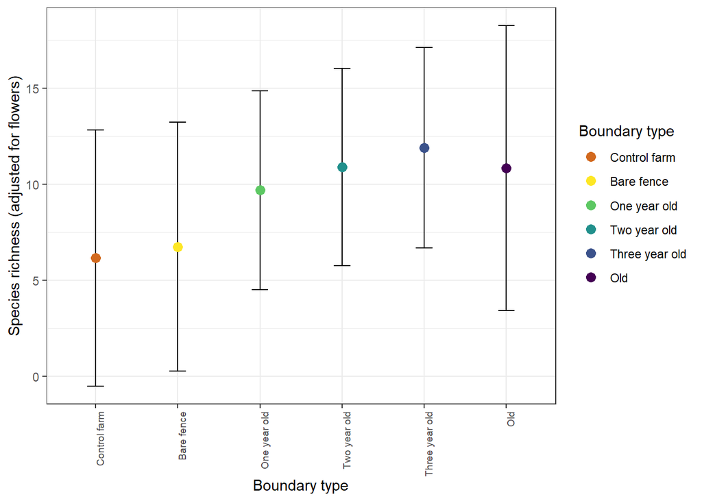

```r
cld_rich$Boundary_descriptor <- factor(cld_rich$Boundary_descriptor,levels=c('Control farm','Bare fence','One year old','Two year old','Three year old','Old'),ordered = T)

ggplot(cld_rich, aes(x = Boundary_descriptor, y = emmean)) +
  theme_bw()+
  geom_errorbar(aes(ymin = lower.CL, ymax = upper.CL), width = 0.2) +
  geom_point(size = 3,aes(colour=Boundary_descriptor)) +
  scale_colour_manual(values=col_bound)+
# not sure if groupings will make sense with facet wrap
#  geom_text(aes(label = .group, y = asymp.UCL + 0.2), vjust = 0, size = 5) +
  labs(y = "Species richness (adjusted for flowers)", x = "Boundary type", colour='Boundary type') +
  theme(axis.text.x = element_text(angle = 90,size=7,hjust=1))
```

## But I think farm and sampling day might need to be in too

Heather Im not sure I’ve got this right and I havent really used emmeans before so Im not sure that is doing the things I think it is doing. I also had a debate in my mind as to whether flower count should be a variable in the model or an offset. To me its more comparable to like a time correction so here I’ve always kept it as a offset but would like your thoughts on that.

```r
#we could model season as a variable
m1<-lm(sppr ~ Boundary_descriptor+Season + offset(log(`Flower count`)), data = meta_data)
#summary(m1)
#exactRLRT(m = m1)

m2<-lmer(sppr ~ Boundary_descriptor+Season + offset(log(`Flower count`)) + (1|Site) , data = meta_data)
```

```
## boundary (singular) fit: see help('isSingular')
```

```r
#summary(m2)

m3<-lmer(sppr ~ Boundary_descriptor+Season + offset(log(`Flower count`)) + (1|Date) , data = meta_data)
#summary(m3)

m4<-lmer(sppr ~ Boundary_descriptor+Season + offset(log(`Flower count`)) + (1|Date) + (1|Site) , data = meta_data)
#summary(m4)

AIC(m1,m2,m3,m4)
```

```
##    df      AIC
## m1  9 617.3474
## m2 10 607.4815
## m3 10 591.1623
## m4 11 592.7171
```

```r
#this probably isnt the best way to compare random effects

#uisng glmmtmb to use reml on lm and assess with anova
logLik(glmmTMB(sppr ~ Boundary_descriptor+Season + offset(log(`Flower count`)), data = meta_data, family = gaussian(), REML=TRUE))
```

```
## 'log Lik.' -293.7408 (df=9)
```

```r
m0<-glmmTMB(sppr ~ Boundary_descriptor+Season + offset(log(`Flower count`)), data = meta_data, family = gaussian(), REML=TRUE)
```

[output not shown]

```r
logLik(glmmTMB(sppr ~ Boundary_descriptor+Season + offset(log(`Flower count`)) + (1|Site) , data = meta_data, family = gaussian(),  REML=TRUE))
```

```
## 'log Lik.' -293.7408 (df=10)
```

```r
m1<-glmmTMB(sppr ~ Boundary_descriptor+Season + offset(log(`Flower count`)) + (1|Site) , data = meta_data, family = gaussian(),  REML=TRUE)
```

[output not shown]

```r
logLik(glmmTMB(sppr ~ Boundary_descriptor+Season + offset(log(`Flower count`)) + (1|Date) , data = meta_data, family = gaussian(),  REML=TRUE))
```

```
## 'log Lik.' -285.5812 (df=10)
```

```r
m2<-glmmTMB(sppr ~ Boundary_descriptor+Season + offset(log(`Flower count`)) + (1|Date) , data = meta_data, family = gaussian(),  REML=TRUE)
#'log Lik.' -285.5812 (df=10)
logLik(glmmTMB(sppr ~ Boundary_descriptor+Season + offset(log(`Flower count`)) + (1|Date) + (1|Site), data = meta_data, family = gaussian(),  REML=TRUE))
```

```
## 'log Lik.' -285.3586 (df=11)
```

```r
m3<-glmmTMB(sppr ~ Boundary_descriptor+Season + offset(log(`Flower count`)) + (1|Date) + (1|Site), data = meta_data, family = gaussian(),  REML=TRUE)
#'log Lik.' -285.3586 (df=11)
AIC(m0,m1,m2,m3)
```

```
##    df      AIC
## m0  9 605.4815
## m1 10 607.4815
## m2 10 591.1623
## m3 11 592.7171
```

```r
anova(m0,m1,m2,m3)
```

```
## Data: meta_data
## Models:
## m0: sppr ~ Boundary_descriptor + Season + offset(log(`Flower count`)), zi=~0, disp=~1
## m1: sppr ~ Boundary_descriptor + Season + offset(log(`Flower count`)) + , zi=~0, disp=~1
## m1:     (1 | Site), zi=~0, disp=~1
## m2: sppr ~ Boundary_descriptor + Season + offset(log(`Flower count`)) + , zi=~0, disp=~1
## m2:     (1 | Date), zi=~0, disp=~1
## m3: sppr ~ Boundary_descriptor + Season + offset(log(`Flower count`)) + , zi=~0, disp=~1
## m3:     (1 | Date) + (1 | Site), zi=~0, disp=~1
##    Df    AIC    BIC  logLik deviance   Chisq Chi Df Pr(>Chisq)
## m0  9 605.48 630.19 -293.74   587.48
## m1 10 607.48 634.93 -293.74   587.48  0.0000      1     1.0000
## m2 10 591.16 618.61 -285.58   571.16 16.3192      0     <2e-16 ***
## m3 11 592.72 622.91 -285.36   570.72  0.4452      1     0.5046
## ---
## Signif. codes:  0 '***' 0.001 '**' 0.01 '*' 0.05 '.' 0.1 ' ' 1
```

```r
#m2 model which has date but no site grouping....

#so date as random effect
m1<-lmer(sppr ~ Boundary_descriptor+Season + offset(log(`Flower count`)) + (1|Date) , data = meta_data)
summary(m1)
```

```
## Linear mixed model fit by REML. t-tests use Satterthwaite's method [
## lmerModLmerTest]
## Formula: sppr ~ Boundary_descriptor + Season + offset(log(`Flower count`)) +
##     (1 | Date)
##    Data: meta_data
##
## REML criterion at convergence: 571.2
##
## Scaled residuals:
##      Min       1Q   Median       3Q      Max
## -1.79933 -0.59386 -0.05895  0.54515  2.81119
##
## Random effects:
##  Groups   Name        Variance Std.Dev.
##  Date     (Intercept) 4.824    2.196
##  Residual             7.359    2.713
## Number of obs: 115, groups:  Date, 32
##
## Fixed effects:
##                                   Estimate Std. Error      df t value Pr(>|t|)
## (Intercept)                         0.7399     1.0261 40.9781   0.721 0.474957
## Boundary_descriptorControl farm    -0.3560     0.7781 90.8533  -0.458 0.648381
## Boundary_descriptorOld              3.9645     0.6975 80.5940   5.684 2.03e-07
## Boundary_descriptorOne year old     2.8114     1.2800 91.5012   2.196 0.030595
## Boundary_descriptorThree year old   5.3072     1.3508 95.7745   3.929 0.000161
## Boundary_descriptorTwo year old     2.9706     1.2314 90.8889   2.412 0.017859
## Season2022/23                      -0.4831     1.2559 29.5454  -0.385 0.703242
## Season2023/24                       2.2385     1.2370 29.7654   1.810 0.080455
##
## (Intercept)
## Boundary_descriptorControl farm
## Boundary_descriptorOld            ***
## Boundary_descriptorOne year old   *
## Boundary_descriptorThree year old ***
## Boundary_descriptorTwo year old   *
## Season2022/23
## Season2023/24                     .
## ---
## Signif. codes:  0 '***' 0.001 '**' 0.01 '*' 0.05 '.' 0.1 ' ' 1
##
## Correlation of Fixed Effects:
##                   (Intr) Bnd_Cf Bndr_O Bn_Oyo Bndry_dscrptrThyo
## Bndry_dscCf       -0.388
## Bndry_dscrO       -0.383  0.524
## Bndry_dsOyo       -0.384  0.335  0.314
## Bndry_dscrptrThyo -0.174  0.356  0.300  0.172
## Bndry_dscrptrTwyo -0.161  0.308  0.327  0.136  0.146
## Sesn2022/23       -0.661  0.020 -0.007  0.183  0.009
## Sesn2023/24       -0.643 -0.046 -0.028  0.144 -0.216
##                   Bndry_dscrptrTwyo S2022/
## Bndry_dscCf
## Bndry_dscrO
## Bndry_dsOyo
## Bndry_dscrptrThyo
## Bndry_dscrptrTwyo
## Sesn2022/23       -0.171
## Sesn2023/24       -0.037             0.544
```

```r
#back transform to species count
emm1 <- emmeans(m1, ~ Boundary_descriptor+Season, type = "response")
#pairwise test
pairs(emm1, simple='each', adjust = "tukey")
```

```
## $`simple contrasts for Boundary_descriptor`
## Season = 2021/22:
##  contrast                      estimate    SE   df t.ratio p.value
##  Bare fence - Control farm        0.356 0.783 91.1   0.455  0.9975
##  Bare fence - Old                -3.965 0.698 81.0  -5.677  <.0001
##  Bare fence - One year old       -2.811 1.290 91.8  -2.181  0.2565
##  Bare fence - Three year old     -5.307 1.360 96.0  -3.894  0.0024
##  Bare fence - Two year old       -2.971 1.240 91.2  -2.396  0.1687
##  Control farm - Old              -4.321 0.728 92.3  -5.932  <.0001
##  Control farm - One year old     -3.167 1.260 87.5  -2.510  0.1324
##  Control farm - Three year old   -5.663 1.310 92.3  -4.336  0.0005
##  Control farm - Two year old     -3.327 1.250 91.3  -2.669  0.0917
##  Old - One year old               1.153 1.260 91.7   0.916  0.9415
##  Old - Three year old            -1.343 1.340 98.2  -1.006  0.9151
##  Old - Two year old               0.994 1.210 91.4   0.822  0.9627
##  One year old - Three year old   -2.496 1.710 93.0  -1.462  0.6890
##  One year old - Two year old     -0.159 1.660 91.4  -0.096  1.0000
##  Three year old - Two year old    2.337 1.710 95.8   1.370  0.7449
##
## Season = 2022/23:
##  contrast                      estimate    SE   df t.ratio p.value
##  Bare fence - Control farm        0.356 0.783 91.1   0.455  0.9975
##  Bare fence - Old                -3.965 0.698 81.0  -5.677  <.0001
##  Bare fence - One year old       -2.811 1.290 91.8  -2.181  0.2565
##  Bare fence - Three year old     -5.307 1.360 96.0  -3.894  0.0024
##  Bare fence - Two year old       -2.971 1.240 91.2  -2.396  0.1687
##  Control farm - Old              -4.321 0.728 92.3  -5.932  <.0001
##  Control farm - One year old     -3.167 1.260 87.5  -2.510  0.1324
##  Control farm - Three year old   -5.663 1.310 92.3  -4.336  0.0005
##  Control farm - Two year old     -3.327 1.250 91.3  -2.669  0.0917
##  Old - One year old               1.153 1.260 91.7   0.916  0.9415
##  Old - Three year old            -1.343 1.340 98.2  -1.006  0.9151
##  Old - Two year old               0.994 1.210 91.4   0.822  0.9627
##  One year old - Three year old   -2.496 1.710 93.0  -1.462  0.6890
##  One year old - Two year old     -0.159 1.660 91.4  -0.096  1.0000
##  Three year old - Two year old    2.337 1.710 95.8   1.370  0.7449
##
## Season = 2023/24:
##  contrast                      estimate    SE   df t.ratio p.value
##  Bare fence - Control farm        0.356 0.783 91.1   0.455  0.9975
```

[output cut: 42 more lines]

```
##
## Boundary_descriptor = Three year old:
##  contrast              estimate   SE   df t.ratio p.value
##  (2021/22) - (2022/23)    0.483 1.26 29.9   0.383  0.9225
##  (2021/22) - (2023/24)   -2.238 1.24 30.2  -1.802  0.1861
##  (2022/23) - (2023/24)   -2.722 1.19 32.0  -2.278  0.0736
##
## Boundary_descriptor = Two year old:
##  contrast              estimate   SE   df t.ratio p.value
##  (2021/22) - (2022/23)    0.483 1.26 29.9   0.383  0.9225
##  (2021/22) - (2023/24)   -2.238 1.24 30.2  -1.802  0.1861
##  (2022/23) - (2023/24)   -2.722 1.19 32.0  -2.278  0.0736
##
## Degrees-of-freedom method: kenward-roger
## P value adjustment: tukey method for comparing a family of 3 estimates
```

```r
#running each as I think all comparisons is a bit over the top and probably repeating things
cld_rich <- multcomp::cld(emm1, Letters = letters, adjust = "tukey")
```

```
## Note: adjust = "tukey" was changed to "sidak"
## because "tukey" is only appropriate for one set of pairwise comparisons
```

```r
colnames(cld_rich)
```

```
## [1] "Boundary_descriptor" "Season"              "emmean"
## [4] "SE"                  "df"                  "lower.CL"
## [7] "upper.CL"            ".group"
```

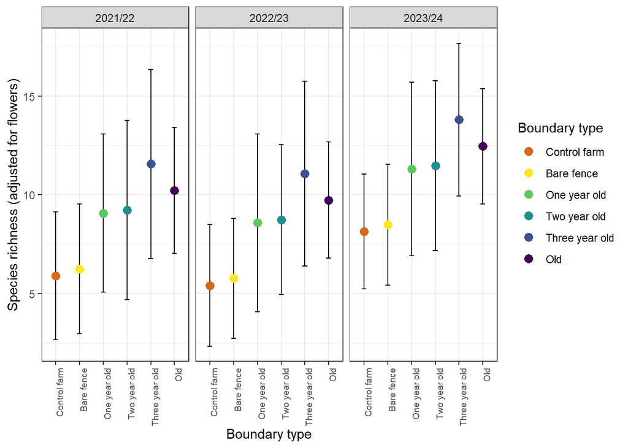

```r
cld_rich$Boundary_descriptor <- factor(cld_rich$Boundary_descriptor,levels=c('Control farm','Bare fence','One year old','Two year old','Three year old','Old'),ordered = T)

ggplot(cld_rich, aes(x = Boundary_descriptor, y = emmean)) +
  facet_wrap(~Season)+
  theme_bw()+
  geom_errorbar(aes(ymin = lower.CL, ymax = upper.CL), width = 0.2) +
  geom_point(size = 3,aes(colour=Boundary_descriptor)) +
  scale_colour_manual(values=col_bound)+
# not sure if groupings will make sense with facet wrap
#  geom_text(aes(label = .group, y = asymp.UCL + 0.2), vjust = 0, size = 5) +
  labs(y = "Species richness (adjusted for flowers)", x = "Boundary type", colour='Boundary type') +
  theme(axis.text.x = element_text(angle = 90,size=7,hjust=1))
```

```r
#I dont really like this for two reasons, 1 im not that interested in season so I kinda like it as a random effect and 2 the figure is funky as emmeans estimates (and makes significant comparisons) for things that were not actually measured (e.g. in 2021/2022 only control, bare,one and old were measured but we have a significant test between 3 and bare)

####season as a random effect

logLik(lmer(sppr ~ Boundary_descriptor + offset(log(`Flower count`))+(1|Season), data = meta_data))
```

```
## 'log Lik.' -298.2743 (df=8)
```

```r
m0<-lmer(sppr ~ Boundary_descriptor + offset(log(`Flower count`))+(1|Season), data = meta_data)
#'log Lik.' -298.2743 (df=8)
logLik(lmer(sppr ~ Boundary_descriptor + offset(log(`Flower count`))+(1|Season) + (1|Site) , data = meta_data))
```

```
## 'log Lik.' -298.2743 (df=9)
```

```r
m1<-lmer(sppr ~ Boundary_descriptor + offset(log(`Flower count`))+(1|Season) + (1|Site) , data = meta_data)
#'log Lik.' -298.2743 (df=9)
logLik(lmer(sppr ~ Boundary_descriptor + offset(log(`Flower count`))+(1|Season) + (1|Date) , data = meta_data))
```

```
## 'log Lik.' -289.7315 (df=9)
```

```r
m2<-lmer(sppr ~ Boundary_descriptor + offset(log(`Flower count`))+(1|Season) + (1|Date) , data = meta_data)
#'log Lik.' -289.7315 (df=9)
logLik(lmer(sppr ~ Boundary_descriptor + offset(log(`Flower count`))+(1|Season) + (1|Date) + (1|Site), data = meta_data))
```

```
## 'log Lik.' -289.4185 (df=10)
```

```r
m3<-lmer(sppr ~ Boundary_descriptor + offset(log(`Flower count`))+(1|Season) + (1|Date) + (1|Site), data = meta_data)
#'log Lik.' -289.4185 (df=10)
AIC(m0,m1,m2,m3)
```

```
##    df      AIC
## m0  8 612.5486
## m1  9 614.5486
## m2  9 597.4629
## m3 10 598.8370
```

```r
anova(m0,m1,m2,m3)
```

```
## refitting model(s) with ML (instead of REML)
```

```
## Data: meta_data
## Models:
## m0: sppr ~ Boundary_descriptor + offset(log(`Flower count`)) + (1 | Season)
## m1: sppr ~ Boundary_descriptor + offset(log(`Flower count`)) + (1 | Season) + (1 | Site)
## m2: sppr ~ Boundary_descriptor + offset(log(`Flower count`)) + (1 | Season) + (1 | Date)
## m3: sppr ~ Boundary_descriptor + offset(log(`Flower count`)) + (1 | Season) + (1 | Date) + (1 | Site)
##    npar    AIC    BIC  logLik -2*log(L)   Chisq Df Pr(>Chisq)
## m0    8 624.27 646.23 -304.14    608.27
## m1    9 626.27 650.98 -304.14    608.27  0.0000  1     1.0000
## m2    9 607.19 631.89 -294.59    589.19 19.0881  0
## m3   10 608.80 636.25 -294.40    588.80  0.3854  1     0.5348
```

```r
anova(m0,m2,m3)
```

```
## refitting model(s) with ML (instead of REML)
```

```
## Data: meta_data
## Models:
## m0: sppr ~ Boundary_descriptor + offset(log(`Flower count`)) + (1 | Season)
## m2: sppr ~ Boundary_descriptor + offset(log(`Flower count`)) + (1 | Season) + (1 | Date)
## m3: sppr ~ Boundary_descriptor + offset(log(`Flower count`)) + (1 | Season) + (1 | Date) + (1 | Site)
##    npar    AIC    BIC  logLik -2*log(L)   Chisq Df Pr(>Chisq)
## m0    8 624.27 646.23 -304.14    608.27
## m2    9 607.19 631.89 -294.59    589.19 19.0881  1  1.248e-05 ***
## m3   10 608.80 636.25 -294.40    588.80  0.3854  1     0.5348
## ---
## Signif. codes:  0 '***' 0.001 '**' 0.01 '*' 0.05 '.' 0.1 ' ' 1
```

```r
anova(m0,m1,m3)
```

```
## refitting model(s) with ML (instead of REML)
```

```
## Data: meta_data
## Models:
## m0: sppr ~ Boundary_descriptor + offset(log(`Flower count`)) + (1 | Season)
## m1: sppr ~ Boundary_descriptor + offset(log(`Flower count`)) + (1 | Season) + (1 | Site)
## m3: sppr ~ Boundary_descriptor + offset(log(`Flower count`)) + (1 | Season) + (1 | Date) + (1 | Site)
##    npar    AIC    BIC  logLik -2*log(L)  Chisq Df Pr(>Chisq)
## m0    8 624.27 646.23 -304.14    608.27
## m1    9 626.27 650.98 -304.14    608.27  0.000  1          1
## m3   10 608.80 636.25 -294.40    588.80 19.474  1   1.02e-05 ***
## ---
## Signif. codes:  0 '***' 0.001 '**' 0.01 '*' 0.05 '.' 0.1 ' ' 1
```

```r
#m2 model

#so date and season as random effect
m2<-lmer(sppr ~ Boundary_descriptor + offset(log(`Flower count`))+(1|Season) + (1|Date) , data = meta_data)
#back transform to species count
emm1 <- emmeans(m1, ~ Boundary_descriptor, type = "response")
#pairwise test
pairs(emm1, simple='each', adjust = "tukey")
```

```
##  contrast                      estimate    SE    df t.ratio p.value
##  Bare fence - Control farm       0.5854 0.917  39.3   0.639  0.9873
##  Bare fence - Old               -4.1078 0.865  38.2  -4.746  0.0004
##  Bare fence - One year old      -2.9445 1.500 102.4  -1.964  0.3702
##  Bare fence - Three year old    -5.1571 1.550 101.5  -3.321  0.0154
##  Bare fence - Two year old      -4.1498 1.430 101.7  -2.904  0.0501
##  Control farm - Old             -4.6933 0.846  36.5  -5.548  <.0001
##  Control farm - One year old    -3.5299 1.500 102.7  -2.356  0.1817
##  Control farm - Three year old  -5.7425 1.510 101.9  -3.798  0.0033
##  Control farm - Two year old    -4.7352 1.430 101.9  -3.315  0.0157
##  Old - One year old              1.1633 1.470 104.2   0.794  0.9680
##  Old - Three year old           -1.0492 1.490 103.1  -0.704  0.9810
##  Old - Two year old             -0.0419 1.390 103.6  -0.030  1.0000
##  One year old - Three year old  -2.2126 1.970  80.7  -1.122  0.8710
##  One year old - Two year old    -1.2053 1.930  81.9  -0.625  0.9888
##  Three year old - Two year old   1.0073 1.920  77.4   0.524  0.9951
##
## Degrees-of-freedom method: kenward-roger
## P value adjustment: tukey method for comparing a family of 6 estimates
```

```r
#running each as I think all comparisons is a bit over the top and probably repeating things
cld_rich <- multcomp::cld(emm1, Letters = letters, adjust = "tukey")
```

```
## Note: adjust = "tukey" was changed to "sidak"
## because "tukey" is only appropriate for one set of pairwise comparisons
```

```r
colnames(cld_rich)
```

```
## [1] "Boundary_descriptor" "emmean"              "SE"
## [4] "df"                  "lower.CL"            "upper.CL"
## [7] ".group"
```

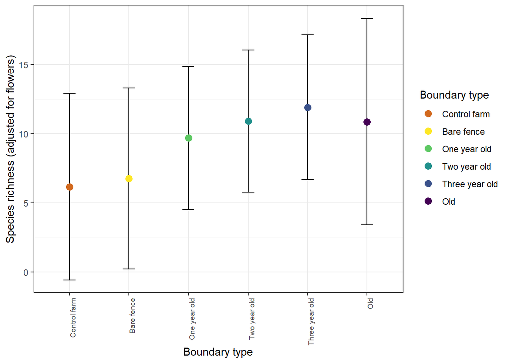

```r
cld_rich$Boundary_descriptor <- factor(cld_rich$Boundary_descriptor,levels=c('Control farm','Bare fence','One year old','Two year old','Three year old','Old'),ordered = T)

ggplot(cld_rich, aes(x = Boundary_descriptor, y = emmean)) +
  theme_bw()+
  geom_errorbar(aes(ymin = lower.CL, ymax = upper.CL), width = 0.2) +
  geom_point(size = 3,aes(colour=Boundary_descriptor)) +
  scale_colour_manual(values=col_bound)+
# not sure if groupings will make sense with facet wrap
#  geom_text(aes(label = .group, y = asymp.UCL + 0.2), vjust = 0, size = 5) +
  labs(y = "Species richness (adjusted for flowers)", x = "Boundary type", colour='Boundary type') +
  theme(axis.text.x = element_text(angle = 90,size=7,hjust=1))
```

## Alpha diversity shannon

Alpha diversity using shannon

```r
shannondiv<-diversity(counts_wide)
head(shannondiv)
```

```
##   Control farm Ahuriri 2021/22   One year old Ahuriri 2021/22
##                      1.0335621                      0.7261928
##   Control farm Ahuriri 2022/23   Two year old Ahuriri 2022/23
##                      1.0986123                      0.0000000
##   Control farm Ahuriri 2023/24 Three year old Ahuriri 2023/24
##                      1.1465958                      2.1730992
```

```r
sppr_aov <-aov(shannondiv ~ Boundary_descriptor, data = meta_data)
summary(sppr_aov)
```

```
##                      Df Sum Sq Mean Sq F value Pr(>F)
## Boundary_descriptor   5  3.866  0.7732   3.154 0.0107 *
## Residuals           109 26.724  0.2452
## ---
## Signif. codes:  0 '***' 0.001 '**' 0.01 '*' 0.05 '.' 0.1 ' ' 1
```

```r
#impact of season and boundary
sppr_aov <-aov(shannondiv ~ Boundary_descriptor+Season, data = meta_data)
summary(sppr_aov)
```

```
##                      Df Sum Sq Mean Sq F value   Pr(>F)
## Boundary_descriptor   5  3.866  0.7732   3.667 0.004212 **
## Season                2  4.162  2.0811   9.870 0.000116 ***
## Residuals           107 22.561  0.2109
## ---
## Signif. codes:  0 '***' 0.001 '**' 0.01 '*' 0.05 '.' 0.1 ' ' 1
```

```r
#impact of season and boundary
sppr_aov <-aov(shannondiv ~ Boundary_descriptor+Season+`Farm type`, data = meta_data)
summary(sppr_aov)
```

```
##                      Df Sum Sq Mean Sq F value   Pr(>F)
## Boundary_descriptor   5  3.866  0.7732   3.650 0.004365 **
## Season                2  4.162  2.0811   9.823 0.000122 ***
## `Farm type`           1  0.105  0.1049   0.495 0.483101
## Residuals           106 22.457  0.2119
## ---
## Signif. codes:  0 '***' 0.001 '**' 0.01 '*' 0.05 '.' 0.1 ' ' 1
```

```r
#####################################################
#######eddys ideal world would have this as the model:
#####################################################
#in the ideal world I would like this as it keeps it in the standard anova framework which makes posthoc tests etc easy:
#flower count as a offset
sppr_aov <-aov(shannondiv ~ Boundary_descriptor + Season + offset(log(`Flower count`)) , data = meta_data)
summary(sppr_aov)
```

```
##                      Df Sum Sq Mean Sq F value   Pr(>F)
## Boundary_descriptor   5  6.131  1.2262   5.345    2e-04 ***
## Season                2  4.676  2.3381  10.192 8.88e-05 ***
## Residuals           107 24.547  0.2294
## ---
## Signif. codes:  0 '***' 0.001 '**' 0.01 '*' 0.05 '.' 0.1 ' ' 1
```

```r
TukeyHSD(sppr_aov)
```

```
##   Tukey multiple comparisons of means
##     95% family-wise confidence level
##
## Fit: aov(formula = shannondiv ~ Boundary_descriptor + Season + offset(log(`Flower count`)), data = meta_data)
##
## $Boundary_descriptor
##                                    diff         lwr         upr     p adj
## Control farm-Bare fence     -0.01434674 -0.38606950  0.35737601 0.9999975
## Old-Bare fence               0.24323929 -0.10857482  0.59505341 0.3456147
## One year old-Bare fence      0.07151073 -0.51803103  0.66105248 0.9992707
## Three year old-Bare fence    0.85396892  0.26442717  1.44351068 0.0007606
## Two year old-Bare fence     -0.20990402 -0.76942086  0.34961281 0.8849051
## Old-Control farm             0.25758604 -0.08714320  0.60231528 0.2612413
## One year old-Control farm    0.08585747 -0.49948393  0.67119887 0.9981754
## Three year old-Control farm  0.86831567  0.28297426  1.45365707 0.0005207
## Two year old-Control farm   -0.19555728 -0.75064661  0.35953205 0.9094861
## One year old-Old            -0.17172857 -0.74463338  0.40117625 0.9528540
## Three year old-Old           0.61072963  0.03782482  1.18363444 0.0295634
## Two year old-Old            -0.45314332 -0.99510230  0.08881566 0.1565291
## Three year old-One year old  0.78245819  0.03948698  1.52542941 0.0328445
## Two year old-One year old   -0.28141475 -1.00079354  0.43796404 0.8655840
## Two year old-Three year old -1.06387295 -1.78325174 -0.34449416 0.0005473
##
## $Season
##                        diff        lwr        upr     p adj
## 2022/23-2021/22 -0.34038613 -0.6033101 -0.0774622 0.0074285
## 2023/24-2021/22  0.08829219 -0.1713688  0.3479531 0.6987991
## 2023/24-2022/23  0.42867832  0.1707983  0.6865583 0.0004085
```

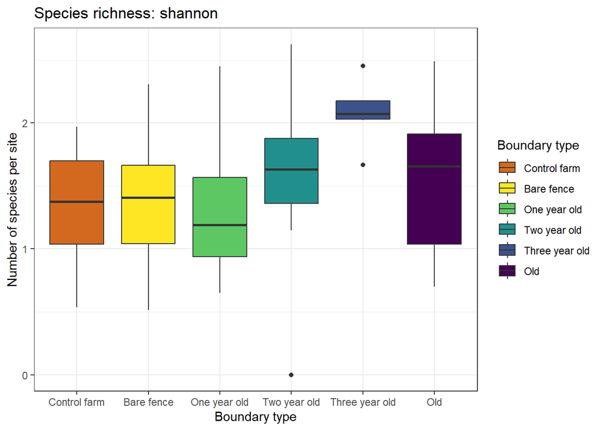

```r
#can plot that out
shannondiv_df <- shannondiv %>%
  enframe() %>%
  full_join(meta_data, by = c("name" = "unique_sample"))

shannondiv_df$Boundary_descriptor <- factor(shannondiv_df$Boundary_descriptor,levels=c('Control farm','Bare fence','One year old','Two year old','Three year old','Old'),ordered = T)


#just boundary
plot_sppr <- ggplot(shannondiv_df, aes(x = Boundary_descriptor, y = value, fill = Boundary_descriptor)) +
  geom_boxplot() +
  theme_bw()+
  scale_fill_manual(values=col_bound)+
  labs(x = "Boundary type",
       y = "Number of species per site",
       title = "Species richness: shannon",
       fill = "Boundary type")
plot_sppr
```

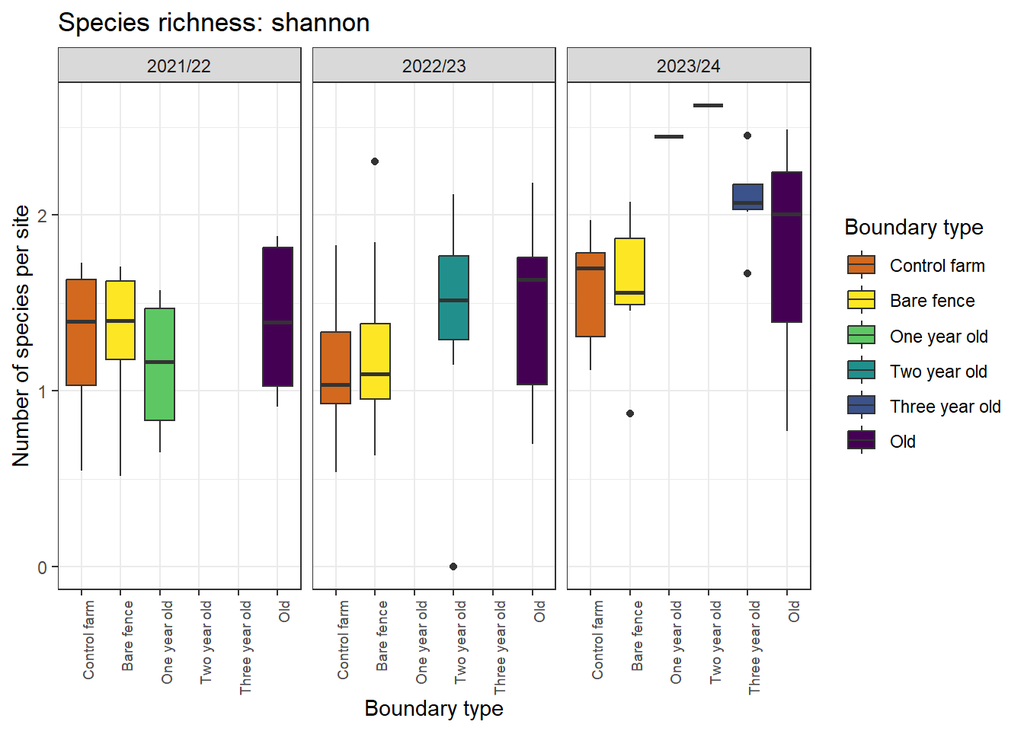

```r
#split by season
plot_sppr <- ggplot(shannondiv_df, aes(x = Boundary_descriptor, y = value, fill = Boundary_descriptor)) +
  geom_boxplot() +
  facet_wrap(~Season)+
  theme_bw()+
  scale_fill_manual(values=col_bound)+
  labs(x = "Boundary type",
       y = "Number of species per site",
       title = "Species richness: shannon",
       fill = "Boundary type")+
  theme(axis.text.x = element_text(angle = 90,size=7,hjust=1))

plot_sppr
```

```r
#again I think that is wrong given that flower number is significant and we have a nested arrangement with site and sampling time

#uisng glmmtmb to use reml on lm and assess with anova
logLik(glmmTMB(shannondiv ~ Boundary_descriptor+Season + offset(log(`Flower count`)), data = meta_data, family = gaussian(), REML=TRUE))
```

```
## 'log Lik.' -84.11753 (df=9)
```

```r
m0<-glmmTMB(shannondiv ~ Boundary_descriptor+Season + offset(log(`Flower count`)), data = meta_data, family = gaussian(), REML=TRUE)
#'log Lik.' -84.12568 (df=9)
logLik(glmmTMB(shannondiv ~ Boundary_descriptor+Season + offset(log(`Flower count`)) + (1|Site) , data = meta_data, family = gaussian(),  REML=TRUE))
```

```
## 'log Lik.' -80.55045 (df=10)
```

```r
m1<-glmmTMB(shannondiv ~ Boundary_descriptor+Season + offset(log(`Flower count`)) + (1|Site) , data = meta_data, family = gaussian(),  REML=TRUE)
#'log Lik.' -80.63598 (df=10)
logLik(glmmTMB(shannondiv ~ Boundary_descriptor+Season + offset(log(`Flower count`)) + (1|Date) , data = meta_data, family = gaussian(),  REML=TRUE))
```

```
## 'log Lik.' -82.72891 (df=10)
```

```r
m2<-glmmTMB(shannondiv ~ Boundary_descriptor+Season + offset(log(`Flower count`)) + (1|Date) , data = meta_data, family = gaussian(),  REML=TRUE)
#'log Lik.' -82.70369 (df=10)
logLik(glmmTMB(shannondiv ~ Boundary_descriptor+Season + offset(log(`Flower count`)) + (1|Date) + (1|Site), data = meta_data, family = gaussian(),  REML=TRUE))
```

```
## 'log Lik.' -78.23447 (df=11)
```

```r
m3<-glmmTMB(shannondiv ~ Boundary_descriptor+Season + offset(log(`Flower count`)) + (1|Date) + (1|Site), data = meta_data, family = gaussian(),  REML=TRUE)
#'log Lik.' -78.34927 (df=11)
AIC(m0,m1,m2,m3) #m3
```

```
##    df      AIC
## m0  9 186.2351
## m1 10 181.1009
## m2 10 185.4578
## m3 11 178.4689
```

```r
anova(m0,m1,m2,m3)
```

```
## Data: meta_data
## Models:
## m0: shannondiv ~ Boundary_descriptor + Season + offset(log(`Flower count`)), zi=~0, disp=~1
## m1: shannondiv ~ Boundary_descriptor + Season + offset(log(`Flower count`)) + , zi=~0, disp=~1
## m1:     (1 | Site), zi=~0, disp=~1
## m2: shannondiv ~ Boundary_descriptor + Season + offset(log(`Flower count`)) + , zi=~0, disp=~1
## m2:     (1 | Date), zi=~0, disp=~1
## m3: shannondiv ~ Boundary_descriptor + Season + offset(log(`Flower count`)) + , zi=~0, disp=~1
## m3:     (1 | Date) + (1 | Site), zi=~0, disp=~1
##    Df    AIC    BIC  logLik deviance  Chisq Chi Df Pr(>Chisq)
## m0  9 186.24 210.94 -84.118   168.24
## m1 10 181.10 208.55 -80.550   161.10 7.1342      1   0.007563 **
## m2 10 185.46 212.91 -82.729   165.46 0.0000      0   1.000000
## m3 11 178.47 208.66 -78.234   156.47 8.9889      1   0.002716 **
## ---
## Signif. codes:  0 '***' 0.001 '**' 0.01 '*' 0.05 '.' 0.1 ' ' 1
```

```r
#m3 model which has date and site grouping....

m3<-lmer(shannondiv ~ Boundary_descriptor+Season + offset(log(`Flower count`)) + (1|Date) + (1|Site), data = meta_data)

emm2 <- emmeans(m3, ~ Boundary_descriptor+Season,type = "response")
pairs(emm2,simple='each',  adjust = "tukey")
```

```
## $`simple contrasts for Boundary_descriptor`
## Season = 2021/22:
##  contrast                      estimate    SE   df t.ratio p.value
##  Bare fence - Control farm      0.02320 0.155 38.7   0.150  1.0000
##  Bare fence - Old              -0.23619 0.144 34.8  -1.640  0.5785
##  Bare fence - One year old      0.01343 0.211 77.0   0.064  1.0000
##  Bare fence - Three year old   -0.58641 0.221 80.8  -2.654  0.0962
##  Bare fence - Two year old     -0.04376 0.205 73.6  -0.214  0.9999
##  Control farm - Old            -0.25939 0.145 37.9  -1.786  0.4866
##  Control farm - One year old   -0.00977 0.208 75.5  -0.047  1.0000
##  Control farm - Three year old -0.60961 0.213 78.5  -2.855  0.0592
##  Control farm - Two year old   -0.06697 0.205 76.0  -0.326  0.9995
##  Old - One year old             0.24962 0.204 79.5   1.225  0.8235
##  Old - Three year old          -0.35022 0.214 84.3  -1.640  0.5747
##  Old - Two year old             0.19243 0.197 76.0   0.975  0.9246
##  One year old - Three year old -0.59984 0.227 70.0  -2.641  0.1010
##  One year old - Two year old   -0.05719 0.223 70.2  -0.257  0.9998
##  Three year old - Two year old  0.54265 0.223 68.8   2.432  0.1598
##
## Season = 2022/23:
##  contrast                      estimate    SE   df t.ratio p.value
##  Bare fence - Control farm      0.02320 0.155 38.7   0.150  1.0000
##  Bare fence - Old              -0.23619 0.144 34.8  -1.640  0.5785
##  Bare fence - One year old      0.01343 0.211 77.0   0.064  1.0000
##  Bare fence - Three year old   -0.58641 0.221 80.8  -2.654  0.0962
##  Bare fence - Two year old     -0.04376 0.205 73.6  -0.214  0.9999
##  Control farm - Old            -0.25939 0.145 37.9  -1.786  0.4866
##  Control farm - One year old   -0.00977 0.208 75.5  -0.047  1.0000
##  Control farm - Three year old -0.60961 0.213 78.5  -2.855  0.0592
##  Control farm - Two year old   -0.06697 0.205 76.0  -0.326  0.9995
##  Old - One year old             0.24962 0.204 79.5   1.225  0.8235
##  Old - Three year old          -0.35022 0.214 84.3  -1.640  0.5747
##  Old - Two year old             0.19243 0.197 76.0   0.975  0.9246
##  One year old - Three year old -0.59984 0.227 70.0  -2.641  0.1010
##  One year old - Two year old   -0.05719 0.223 70.2  -0.257  0.9998
##  Three year old - Two year old  0.54265 0.223 68.8   2.432  0.1598
##
## Season = 2023/24:
##  contrast                      estimate    SE   df t.ratio p.value
##  Bare fence - Control farm      0.02320 0.155 38.7   0.150  1.0000
```

[output cut: 42 more lines]

```
##
## Boundary_descriptor = Three year old:
##  contrast              estimate    SE   df t.ratio p.value
##  (2021/22) - (2022/23)    0.412 0.136 21.5   3.026  0.0167
##  (2021/22) - (2023/24)   -0.138 0.137 23.2  -1.004  0.5818
##  (2022/23) - (2023/24)   -0.550 0.133 25.3  -4.146  0.0009
##
## Boundary_descriptor = Two year old:
##  contrast              estimate    SE   df t.ratio p.value
##  (2021/22) - (2022/23)    0.412 0.136 21.5   3.026  0.0167
##  (2021/22) - (2023/24)   -0.138 0.137 23.2  -1.004  0.5818
##  (2022/23) - (2023/24)   -0.550 0.133 25.3  -4.146  0.0009
##
## Degrees-of-freedom method: kenward-roger
## P value adjustment: tukey method for comparing a family of 3 estimates
```

```r
#running each as I think all comparisons is a bit over the top and probably repeating things
cld_rich <- multcomp::cld(emm2, Letters = letters, adjust = "tukey")
```

```
## Note: adjust = "tukey" was changed to "sidak"
## because "tukey" is only appropriate for one set of pairwise comparisons
```

```r
colnames(cld_rich)
```

```
## [1] "Boundary_descriptor" "Season"              "emmean"
## [4] "SE"                  "df"                  "lower.CL"
## [7] "upper.CL"            ".group"
```

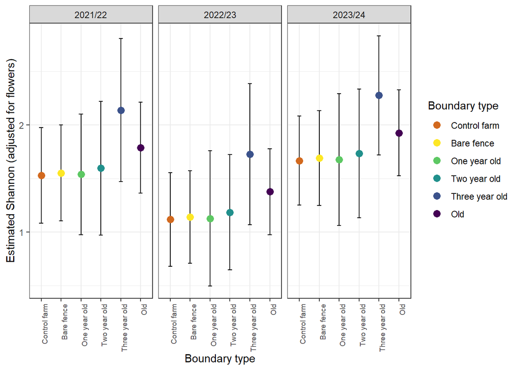

```r
cld_rich$Boundary_descriptor <- factor(cld_rich$Boundary_descriptor,levels=c('Control farm','Bare fence','One year old','Two year old','Three year old','Old'),ordered = T)

ggplot(cld_rich, aes(x = Boundary_descriptor, y = emmean)) +
  facet_wrap(~Season)+
  theme_bw()+
  geom_errorbar(aes(ymin = lower.CL, ymax = upper.CL), width = 0.2) +
  geom_point(size = 3,aes(colour=Boundary_descriptor)) +
  scale_colour_manual(values=col_bound)+
# not sure if groupings will make sense with facet wrap
#  geom_text(aes(label = .group, y = asymp.UCL + 0.2), vjust = 0, size = 5) +
  labs(y = "Estimated Shannon (adjusted for flowers)", x = "Boundary type", colour='Boundary type') +
  theme(axis.text.x = element_text(angle = 90,size=7,hjust=1))
```

```r
####season as random effect
logLik(lmer(shannondiv ~ Boundary_descriptor+ offset(log(`Flower count`))+(1|Season), data = meta_data))
```

```
## 'log Lik.' -84.87288 (df=8)
```

```r
m0<-lmer(shannondiv ~ Boundary_descriptor+ offset(log(`Flower count`))+(1|Season), data = meta_data)
#'log Lik.' -84.87288 (df=8)
logLik(lmer(shannondiv ~ Boundary_descriptor+ offset(log(`Flower count`))+(1|Season) + (1|Site) , data = meta_data))
```

```
## 'log Lik.' -81.24076 (df=9)
```

```r
m1<-lmer(shannondiv ~ Boundary_descriptor+ offset(log(`Flower count`))+(1|Season) + (1|Site) , data = meta_data)
#'log Lik.' -81.24076 (df=9)
logLik(lmer(shannondiv ~ Boundary_descriptor+ offset(log(`Flower count`))+(1|Season) + (1|Date) , data = meta_data))
```

```
## 'log Lik.' -83.57334 (df=9)
```

```r
m2<-lmer(shannondiv ~ Boundary_descriptor+ offset(log(`Flower count`))+(1|Season) + (1|Date) , data = meta_data)
#'log Lik.' -83.57334 (df=9)
logLik(lmer(shannondiv ~ Boundary_descriptor+ offset(log(`Flower count`))+(1|Season) + (1|Date) + (1|Site), data = meta_data))
```

```
## 'log Lik.' -79.12032 (df=10)
```

```r
m3<-lmer(shannondiv ~ Boundary_descriptor+ offset(log(`Flower count`))+(1|Season) + (1|Date) + (1|Site), data = meta_data)
#'log Lik.' -79.12032 (df=10)

AIC(m0,m1,m2,m3) #m3
```

```
##    df      AIC
## m0  8 185.7458
## m1  9 180.4815
## m2  9 185.1467
## m3 10 178.2406
```

```r
anova(m0,m1,m2,m3)
```

```
## refitting model(s) with ML (instead of REML)
```

```
## Data: meta_data
## Models:
## m0: shannondiv ~ Boundary_descriptor + offset(log(`Flower count`)) + (1 | Season)
## m1: shannondiv ~ Boundary_descriptor + offset(log(`Flower count`)) + (1 | Season) + (1 | Site)
## m2: shannondiv ~ Boundary_descriptor + offset(log(`Flower count`)) + (1 | Season) + (1 | Date)
## m3: shannondiv ~ Boundary_descriptor + offset(log(`Flower count`)) + (1 | Season) + (1 | Date) + (1 | Site)
##    npar    AIC    BIC  logLik -2*log(L)  Chisq Df Pr(>Chisq)
## m0    8 174.11 196.07 -79.055    158.11
## m1    9 169.46 194.16 -75.727    151.46 6.6548  1   0.009889 **
## m2    9 173.25 197.96 -77.628    155.25 0.0000  0
## m3   10 167.08 194.53 -73.542    147.08 8.1721  1   0.004254 **
## ---
## Signif. codes:  0 '***' 0.001 '**' 0.01 '*' 0.05 '.' 0.1 ' ' 1
```

```r
anova(m1,m3)
```

```
## refitting model(s) with ML (instead of REML)
```

```
## Data: meta_data
## Models:
## m1: shannondiv ~ Boundary_descriptor + offset(log(`Flower count`)) + (1 | Season) + (1 | Site)
## m3: shannondiv ~ Boundary_descriptor + offset(log(`Flower count`)) + (1 | Season) + (1 | Date) + (1 | Site)
##    npar    AIC    BIC  logLik -2*log(L)  Chisq Df Pr(>Chisq)
## m1    9 169.46 194.16 -75.727    151.46
## m3   10 167.08 194.53 -73.542    147.08 4.3716  1    0.03654 *
## ---
## Signif. codes:  0 '***' 0.001 '**' 0.01 '*' 0.05 '.' 0.1 ' ' 1
```

```r
#m3 model which has date and site grouping....

m3<-lmer(shannondiv ~ Boundary_descriptor+ offset(log(`Flower count`))+(1|Season) + (1|Date) + (1|Site), data = meta_data)

emm2 <- emmeans(m3, ~ Boundary_descriptor,type = "response")
pairs(emm2,simple='each',  adjust = "tukey")
```

```
##  contrast                      estimate    SE   df t.ratio p.value
##  Bare fence - Control farm      0.01948 0.155 38.8   0.126  1.0000
##  Bare fence - Old              -0.23749 0.144 34.9  -1.648  0.5738
##  Bare fence - One year old      0.00513 0.211 77.2   0.024  1.0000
##  Bare fence - Three year old   -0.60770 0.222 81.1  -2.739  0.0786
##  Bare fence - Two year old     -0.02903 0.205 73.7  -0.142  1.0000
##  Control farm - Old            -0.25696 0.145 37.9  -1.769  0.4972
##  Control farm - One year old   -0.01435 0.209 75.7  -0.069  1.0000
##  Control farm - Three year old -0.62717 0.214 78.8  -2.927  0.0492
##  Control farm - Two year old   -0.04851 0.206 76.2  -0.236  0.9999
##  Old - One year old             0.24262 0.204 79.7   1.187  0.8418
##  Old - Three year old          -0.37021 0.214 84.6  -1.728  0.5178
##  Old - Two year old             0.20845 0.198 76.2   1.053  0.8981
##  One year old - Three year old -0.61283 0.229 71.1  -2.679  0.0924
##  One year old - Two year old   -0.03417 0.224 71.5  -0.152  1.0000
##  Three year old - Two year old  0.57866 0.225 70.0   2.574  0.1175
##
## Degrees-of-freedom method: kenward-roger
## P value adjustment: tukey method for comparing a family of 6 estimates
```

```r
#running each as I think all comparisons is a bit over the top and probably repeating things
cld_rich <- multcomp::cld(emm2, Letters = letters, adjust = "tukey")
```

```
## Note: adjust = "tukey" was changed to "sidak"
## because "tukey" is only appropriate for one set of pairwise comparisons
```

```r
colnames(cld_rich)
```

```
## [1] "Boundary_descriptor" "emmean"              "SE"
## [4] "df"                  "lower.CL"            "upper.CL"
## [7] ".group"
```

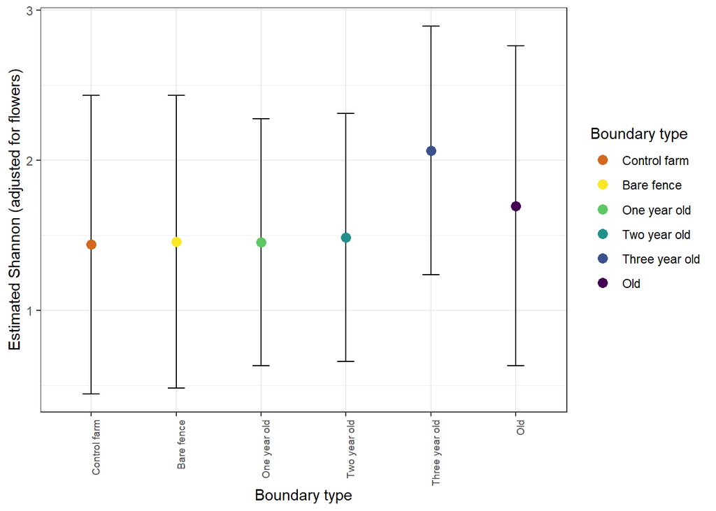

```r
cld_rich$Boundary_descriptor <- factor(cld_rich$Boundary_descriptor,levels=c('Control farm','Bare fence','One year old','Two year old','Three year old','Old'),ordered = T)

ggplot(cld_rich, aes(x = Boundary_descriptor, y = emmean)) +
#  facet_wrap(~Season)+
  theme_bw()+
  geom_errorbar(aes(ymin = lower.CL, ymax = upper.CL), width = 0.2) +
  geom_point(size = 3,aes(colour=Boundary_descriptor)) +
  scale_colour_manual(values=col_bound)+
# not sure if groupings will make sense with facet wrap
#  geom_text(aes(label = .group, y = asymp.UCL + 0.2), vjust = 0, size = 5) +
  labs(y = "Estimated Shannon (adjusted for flowers)", x = "Boundary type", colour='Boundary type') +
  theme(axis.text.x = element_text(angle = 90,size=7,hjust=1))
```

## Alpha diversity simpson

Alpha diversity using simpson

```r
simpsondiv<-diversity(counts_wide,index='simpson')
head(simpsondiv)
```

```
##   Control farm Ahuriri 2021/22   One year old Ahuriri 2021/22
##                      0.5454545                      0.3223140
##   Control farm Ahuriri 2022/23   Two year old Ahuriri 2022/23
##                      0.6666667                      0.0000000
##   Control farm Ahuriri 2023/24 Three year old Ahuriri 2023/24
##                      0.5867769                      0.8310322
```

```r
sppr_aov <-aov(simpsondiv ~ Boundary_descriptor, data = meta_data)
summary(sppr_aov)
```

```
##                      Df Sum Sq Mean Sq F value Pr(>F)
## Boundary_descriptor   5  0.270 0.05404   1.674  0.147
## Residuals           109  3.519 0.03229
```

```r
#impact of season and boundary
sppr_aov <-aov(simpsondiv ~ Boundary_descriptor+Season, data = meta_data)
summary(sppr_aov)
```

```
##                      Df Sum Sq Mean Sq F value  Pr(>F)
## Boundary_descriptor   5  0.270 0.05404   1.806 0.11768
## Season                2  0.319 0.15935   5.327 0.00623 **
## Residuals           107  3.201 0.02991
## ---
## Signif. codes:  0 '***' 0.001 '**' 0.01 '*' 0.05 '.' 0.1 ' ' 1
```

```r
#impact of season and boundary
sppr_aov <-aov(simpsondiv ~ Boundary_descriptor+Season+`Farm type`, data = meta_data)
summary(sppr_aov)
```

```
##                      Df Sum Sq Mean Sq F value  Pr(>F)
## Boundary_descriptor   5  0.270 0.05404   1.807 0.11768
## Season                2  0.319 0.15935   5.328 0.00624 **
## `Farm type`           1  0.031 0.03067   1.025 0.31353
## Residuals           106  3.170 0.02991
## ---
## Signif. codes:  0 '***' 0.001 '**' 0.01 '*' 0.05 '.' 0.1 ' ' 1
```

```r
#####################################################
#######eddys ideal world would have this as the model:
#####################################################
#in the ideal world I would like this as it keeps it in the standard anova framework which makes posthoc tests etc easy:
#flower count as a offset
sppr_aov <-aov(simpsondiv  ~ Boundary_descriptor + Season + offset(log(`Flower count`)) , data = meta_data)
summary(sppr_aov)
```

```
##                      Df Sum Sq Mean Sq F value   Pr(>F)
## Boundary_descriptor   5  1.895  0.3790   3.399 0.006867 **
## Season                2  1.991  0.9957   8.931 0.000259 ***
## Residuals           107 11.929  0.1115
## ---
## Signif. codes:  0 '***' 0.001 '**' 0.01 '*' 0.05 '.' 0.1 ' ' 1
```

```r
TukeyHSD(sppr_aov)
```

```
##   Tukey multiple comparisons of means
##     95% family-wise confidence level
##
## Fit: aov(formula = simpsondiv ~ Boundary_descriptor + Season + offset(log(`Flower count`)), data = meta_data)
##
## $Boundary_descriptor
##                                     diff         lwr          upr     p adj
## Control farm-Bare fence      0.006384924 -0.25274529  0.265515134 0.9999997
## Old-Bare fence               0.055213358 -0.19003842  0.300465133 0.9864785
## One year old-Bare fence      0.024451619 -0.38652155  0.435424790 0.9999781
## Three year old-Bare fence    0.314598374 -0.09637480  0.725571545 0.2366692
## Two year old-Bare fence     -0.371965903 -0.76200852  0.018076715 0.0707504
## Old-Control farm             0.048828435 -0.19148443  0.289141300 0.9915338
## One year old-Control farm    0.018066695 -0.38997839  0.426111776 0.9999950
## Three year old-Control farm  0.308213450 -0.09983163  0.716258531 0.2501229
## Two year old-Control farm   -0.378350826 -0.76530700  0.008605352 0.0591983
## One year old-Old            -0.030761740 -0.43013720  0.368613717 0.9999214
## Three year old-Old           0.259385015 -0.13999044  0.658760472 0.4171238
## Two year old-Old            -0.427179261 -0.80498219 -0.049376335 0.0170890
## Three year old-One year old  0.290146755 -0.22778304  0.808076548 0.5835275
## Two year old-One year old   -0.396417521 -0.89790089  0.105065844 0.2056298
## Two year old-Three year old -0.686564276 -1.18804764 -0.185080911 0.0017570
##
## $Season
##                       diff         lwr         upr     p adj
## 2022/23-2021/22 -0.3004747 -0.48376058 -0.11718882 0.0004970
## 2023/24-2021/22 -0.1554555 -0.33646671  0.02555577 0.1073967
## 2023/24-2022/23  0.1450192 -0.03475049  0.32478895 0.1387459
```

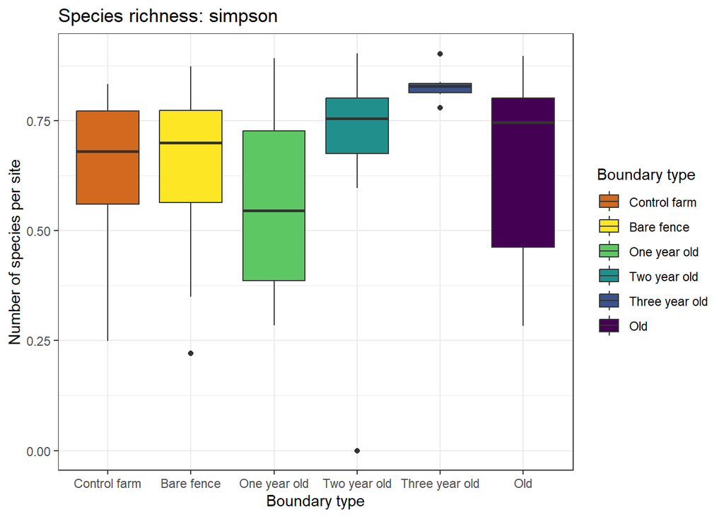

```r
#can plot that out
simpsondiv_df <- simpsondiv %>%
  enframe() %>%
  full_join(meta_data, by = c("name" = "unique_sample"))

simpsondiv_df$Boundary_descriptor <- factor(simpsondiv_df$Boundary_descriptor,levels=c('Control farm','Bare fence','One year old','Two year old','Three year old','Old'),ordered = T)


#just boundary
plot_sppr <- ggplot(simpsondiv_df, aes(x = Boundary_descriptor, y = value, fill = Boundary_descriptor)) +
  geom_boxplot() +
  theme_bw()+
  scale_fill_manual(values=col_bound)+
  labs(x = "Boundary type",
       y = "Number of species per site",
       title = "Species richness: simpson",
       fill = "Boundary type")
plot_sppr
```

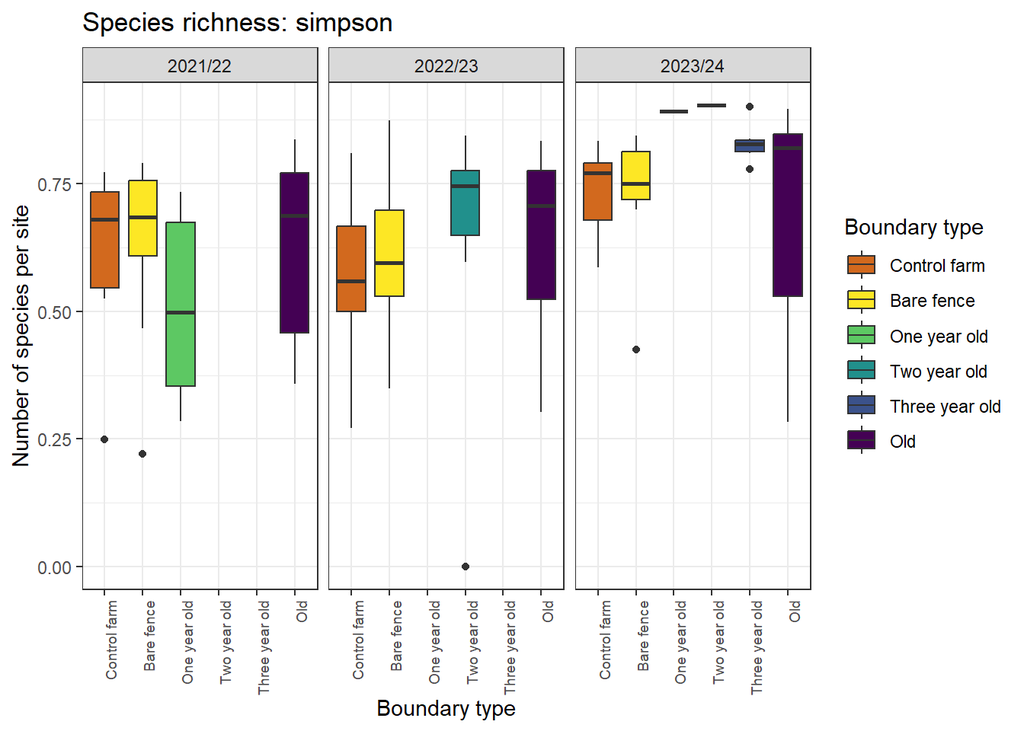

```r
#split by season
plot_sppr <- ggplot(simpsondiv_df, aes(x = Boundary_descriptor, y = value, fill = Boundary_descriptor)) +
  geom_boxplot() +
  facet_wrap(~Season)+
  theme_bw()+
  scale_fill_manual(values=col_bound)+
  labs(x = "Boundary type",
       y = "Number of species per site",
       title = "Species richness: simpson",
       fill = "Boundary type")+
  theme(axis.text.x = element_text(angle = 90,size=7,hjust=1))

plot_sppr
```

```r
##again I think that is wrong given that flower number is significant and we have a nested arrangement with site and sampling time

#uisng glmmtmb to use reml on lm and assess with anova
logLik(glmmTMB(simpsondiv ~ Boundary_descriptor+Season + offset(log(`Flower count`)), data = meta_data, family = gaussian(), REML=TRUE))
```

```
## 'log Lik.' -45.51004 (df=9)
```

```r
m0<-glmmTMB(simpsondiv ~ Boundary_descriptor+Season + offset(log(`Flower count`)), data = meta_data, family = gaussian(), REML=TRUE)
#'log Lik.' -45.51004 (df=9)
logLik(glmmTMB(simpsondiv ~ Boundary_descriptor+Season + offset(log(`Flower count`)) + (1|Site) , data = meta_data, family = gaussian(),  REML=TRUE))
```

```
## 'log Lik.' -45.05968 (df=10)
```

```r
m1<-glmmTMB(simpsondiv ~ Boundary_descriptor+Season + offset(log(`Flower count`)) + (1|Site) , data = meta_data, family = gaussian(),  REML=TRUE)
#'log Lik.' -45.05968 (df=10)
logLik(glmmTMB(simpsondiv ~ Boundary_descriptor+Season + offset(log(`Flower count`)) + (1|Date) , data = meta_data, family = gaussian(),  REML=TRUE))
```

```
## 'log Lik.' -40.84054 (df=10)
```

```r
m2<-glmmTMB(simpsondiv ~ Boundary_descriptor+Season + offset(log(`Flower count`)) + (1|Date) , data = meta_data, family = gaussian(),  REML=TRUE)
#'log Lik.' -40.84054 (df=10)
logLik(glmmTMB(simpsondiv ~ Boundary_descriptor+Season + offset(log(`Flower count`)) + (1|Date) + (1|Site), data = meta_data, family = gaussian(),  REML=TRUE))
```

```
## 'log Lik.' -37.21097 (df=11)
```

```r
m3<-glmmTMB(simpsondiv ~ Boundary_descriptor+Season + offset(log(`Flower count`)) + (1|Date) + (1|Site), data = meta_data, family = gaussian(),  REML=TRUE)
#'log Lik.' -37.21097 (df=11)
AIC(m0,m1,m2,m3) #m3
```

```
##    df       AIC
## m0  9 109.02009
## m1 10 110.11935
## m2 10 101.68107
## m3 11  96.42194
```

```r
anova(m0,m1,m2,m3)
```

```
## Data: meta_data
## Models:
## m0: simpsondiv ~ Boundary_descriptor + Season + offset(log(`Flower count`)), zi=~0, disp=~1
## m1: simpsondiv ~ Boundary_descriptor + Season + offset(log(`Flower count`)) + , zi=~0, disp=~1
## m1:     (1 | Site), zi=~0, disp=~1
## m2: simpsondiv ~ Boundary_descriptor + Season + offset(log(`Flower count`)) + , zi=~0, disp=~1
## m2:     (1 | Date), zi=~0, disp=~1
## m3: simpsondiv ~ Boundary_descriptor + Season + offset(log(`Flower count`)) + , zi=~0, disp=~1
## m3:     (1 | Date) + (1 | Site), zi=~0, disp=~1
##    Df     AIC    BIC  logLik deviance  Chisq Chi Df Pr(>Chisq)
## m0  9 109.020 133.72 -45.510   91.020
## m1 10 110.119 137.57 -45.060   90.119 0.9007      1   0.342584
## m2 10 101.681 129.13 -40.841   81.681 8.4383      0  < 2.2e-16 ***
## m3 11  96.422 126.62 -37.211   74.422 7.2591      1   0.007054 **
## ---
## Signif. codes:  0 '***' 0.001 '**' 0.01 '*' 0.05 '.' 0.1 ' ' 1
```

```r
anova(m2,m3)
```

```
## Data: meta_data
## Models:
## m2: simpsondiv ~ Boundary_descriptor + Season + offset(log(`Flower count`)) + , zi=~0, disp=~1
## m2:     (1 | Date), zi=~0, disp=~1
## m3: simpsondiv ~ Boundary_descriptor + Season + offset(log(`Flower count`)) + , zi=~0, disp=~1
## m3:     (1 | Date) + (1 | Site), zi=~0, disp=~1
##    Df     AIC    BIC  logLik deviance  Chisq Chi Df Pr(>Chisq)
## m2 10 101.681 129.13 -40.841   81.681
## m3 11  96.422 126.62 -37.211   74.422 7.2591      1   0.007054 **
## ---
## Signif. codes:  0 '***' 0.001 '**' 0.01 '*' 0.05 '.' 0.1 ' ' 1
```

```r
#m3 model which has date and site grouping....
m3<-lmer(simpsondiv ~ Boundary_descriptor+Season + offset(log(`Flower count`)) + (1|Date) + (1|Site), data = meta_data)

emm2 <- emmeans(m3, ~ Boundary_descriptor+Season,type = "response")
pairs(emm2,simple='each',  adjust = "tukey")
```

```
## $`simple contrasts for Boundary_descriptor`
## Season = 2021/22:
##  contrast                      estimate     SE   df t.ratio p.value
##  Bare fence - Control farm      -0.0251 0.0998 36.9  -0.252  0.9999
##  Bare fence - Old               -0.0788 0.0912 32.2  -0.864  0.9523
##  Bare fence - One year old       0.0822 0.1360 73.8   0.602  0.9906
##  Bare fence - Three year old    -0.1804 0.1440 78.1  -1.250  0.8109
##  Bare fence - Two year old       0.0720 0.1320 69.7   0.545  0.9941
##  Control farm - Old             -0.0537 0.0941 36.2  -0.571  0.9923
##  Control farm - One year old     0.1073 0.1340 70.7   0.802  0.9662
##  Control farm - Three year old  -0.1553 0.1380 74.6  -1.124  0.8698
##  Control farm - Two year old     0.0972 0.1330 71.0   0.730  0.9775
##  Old - One year old              0.1610 0.1320 76.3   1.220  0.8257
##  Old - Three year old           -0.1016 0.1400 82.0  -0.724  0.9784
##  Old - Two year old              0.1509 0.1280 72.2   1.181  0.8443
##  One year old - Three year old  -0.2626 0.1480 64.1  -1.775  0.4890
##  One year old - Two year old    -0.0102 0.1450 64.3  -0.070  1.0000
##  Three year old - Two year old   0.2525 0.1460 62.8   1.726  0.5205
##
## Season = 2022/23:
##  contrast                      estimate     SE   df t.ratio p.value
##  Bare fence - Control farm      -0.0251 0.0998 36.9  -0.252  0.9999
##  Bare fence - Old               -0.0788 0.0912 32.2  -0.864  0.9523
##  Bare fence - One year old       0.0822 0.1360 73.8   0.602  0.9906
##  Bare fence - Three year old    -0.1804 0.1440 78.1  -1.250  0.8109
##  Bare fence - Two year old       0.0720 0.1320 69.7   0.545  0.9941
##  Control farm - Old             -0.0537 0.0941 36.2  -0.571  0.9923
##  Control farm - One year old     0.1073 0.1340 70.7   0.802  0.9662
##  Control farm - Three year old  -0.1553 0.1380 74.6  -1.124  0.8698
##  Control farm - Two year old     0.0972 0.1330 71.0   0.730  0.9775
##  Old - One year old              0.1610 0.1320 76.3   1.220  0.8257
##  Old - Three year old           -0.1016 0.1400 82.0  -0.724  0.9784
##  Old - Two year old              0.1509 0.1280 72.2   1.181  0.8443
##  One year old - Three year old  -0.2626 0.1480 64.1  -1.775  0.4890
##  One year old - Two year old    -0.0102 0.1450 64.3  -0.070  1.0000
##  Three year old - Two year old   0.2525 0.1460 62.8   1.726  0.5205
##
## Season = 2023/24:
##  contrast                      estimate     SE   df t.ratio p.value
##  Bare fence - Control farm      -0.0251 0.0998 36.9  -0.252  0.9999
```

[output cut: 42 more lines]

```
##
## Boundary_descriptor = Three year old:
##  contrast              estimate    SE   df t.ratio p.value
##  (2021/22) - (2022/23)   0.4069 0.117 25.1   3.470  0.0052
##  (2021/22) - (2023/24)   0.0964 0.117 26.6   0.825  0.6910
##  (2022/23) - (2023/24)  -0.3105 0.112 27.7  -2.769  0.0260
##
## Boundary_descriptor = Two year old:
##  contrast              estimate    SE   df t.ratio p.value
##  (2021/22) - (2022/23)   0.4069 0.117 25.1   3.470  0.0052
##  (2021/22) - (2023/24)   0.0964 0.117 26.6   0.825  0.6910
##  (2022/23) - (2023/24)  -0.3105 0.112 27.7  -2.769  0.0260
##
## Degrees-of-freedom method: kenward-roger
## P value adjustment: tukey method for comparing a family of 3 estimates
```

```r
#running each as I think all comparisons is a bit over the top and probably repeating things
cld_rich <- multcomp::cld(emm2, Letters = letters, adjust = "tukey")
```

```
## Note: adjust = "tukey" was changed to "sidak"
## because "tukey" is only appropriate for one set of pairwise comparisons
```

```r
colnames(cld_rich)
```

```
## [1] "Boundary_descriptor" "Season"              "emmean"
## [4] "SE"                  "df"                  "lower.CL"
## [7] "upper.CL"            ".group"
```

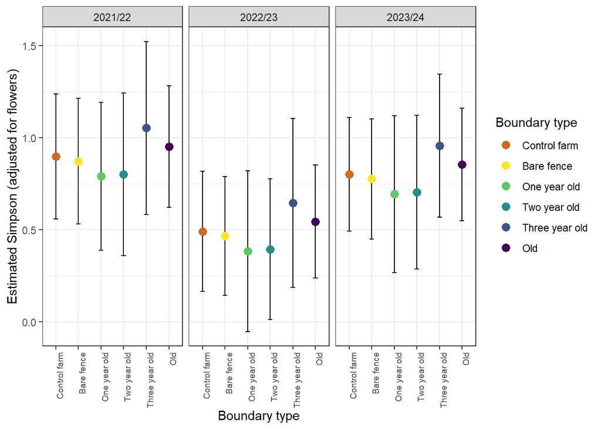

```r
cld_rich$Boundary_descriptor <- factor(cld_rich$Boundary_descriptor,levels=c('Control farm','Bare fence','One year old','Two year old','Three year old','Old'),ordered = T)

ggplot(cld_rich, aes(x = Boundary_descriptor, y = emmean)) +
  facet_wrap(~Season)+
  theme_bw()+
  geom_errorbar(aes(ymin = lower.CL, ymax = upper.CL), width = 0.2) +
  geom_point(size = 3,aes(colour=Boundary_descriptor)) +
  scale_colour_manual(values=col_bound)+
# not sure if groupings will make sense with facet wrap
#  geom_text(aes(label = .group, y = asymp.UCL + 0.2), vjust = 0, size = 5) +
  labs(y = "Estimated Simpson (adjusted for flowers)", x = "Boundary type", colour='Boundary type') +
  theme(axis.text.x = element_text(angle = 90,size=7,hjust=1))
```

```r
####season as random effect
logLik(lmer(simpsondiv ~ Boundary_descriptor+ offset(log(`Flower count`))+(1|Season), data = meta_data))
```

```
## 'log Lik.' -45.42901 (df=8)
```

```r
m0<-lmer(shannondiv ~ Boundary_descriptor+ offset(log(`Flower count`))+(1|Season), data = meta_data)
#'log Lik.' -45.42901 (df=8)
logLik(lmer(simpsondiv ~ Boundary_descriptor+ offset(log(`Flower count`))+(1|Season) + (1|Site) , data = meta_data))
```

```
## 'log Lik.' -44.97961 (df=9)
```

```r
m1<-lmer(simpsondiv ~ Boundary_descriptor+ offset(log(`Flower count`))+(1|Season) + (1|Site) , data = meta_data)
#'log Lik.' -44.97961 (df=9)
logLik(lmer(simpsondiv ~ Boundary_descriptor+ offset(log(`Flower count`))+(1|Season) + (1|Date) , data = meta_data))
```

```
## 'log Lik.' -40.9589 (df=9)
```

```r
m2<-lmer(simpsondiv ~ Boundary_descriptor+ offset(log(`Flower count`))+(1|Season) + (1|Date) , data = meta_data)
#'log Lik.' -40.9589 (df=9)
logLik(lmer(simpsondiv ~ Boundary_descriptor+ offset(log(`Flower count`))+(1|Season) + (1|Date) + (1|Site), data = meta_data))
```

```
## 'log Lik.' -37.49932 (df=10)
```

```r
m3<-lmer(simpsondiv ~ Boundary_descriptor+ offset(log(`Flower count`))+(1|Season) + (1|Date) + (1|Site), data = meta_data)
#'log Lik.' -37.49932 (df=10)

AIC(m0,m1,m2,m3) #m3
```

```
##    df       AIC
## m0  8 185.74577
## m1  9 107.95922
## m2  9  99.91780
## m3 10  94.99863
```

```r
anova(m0,m1,m2,m3)
```

```
## refitting model(s) with ML (instead of REML)
```

```
## Data: meta_data
## Models:
## m0: shannondiv ~ Boundary_descriptor + offset(log(`Flower count`)) + (1 | Season)
## m1: simpsondiv ~ Boundary_descriptor + offset(log(`Flower count`)) + (1 | Season) + (1 | Site)
## m2: simpsondiv ~ Boundary_descriptor + offset(log(`Flower count`)) + (1 | Season) + (1 | Date)
## m3: simpsondiv ~ Boundary_descriptor + offset(log(`Flower count`)) + (1 | Season) + (1 | Date) + (1 | Site)
##    npar     AIC    BIC  logLik -2*log(L)   Chisq Df Pr(>Chisq)
## m0    8 174.110 196.07 -79.055   158.110
## m1    9  92.183 116.89 -37.092    74.183 83.9264  1     <2e-16 ***
## m2    9  82.999 107.70 -32.500    64.999  9.1841  0
## m3   10  78.857 106.31 -29.428    58.857  6.1426  1     0.0132 *
## ---
## Signif. codes:  0 '***' 0.001 '**' 0.01 '*' 0.05 '.' 0.1 ' ' 1
```

```r
anova(m1,m3)
```

```
## refitting model(s) with ML (instead of REML)
```

```
## Data: meta_data
## Models:
## m1: simpsondiv ~ Boundary_descriptor + offset(log(`Flower count`)) + (1 | Season) + (1 | Site)
## m3: simpsondiv ~ Boundary_descriptor + offset(log(`Flower count`)) + (1 | Season) + (1 | Date) + (1 | Site)
##    npar    AIC    BIC  logLik -2*log(L)  Chisq Df Pr(>Chisq)
## m1    9 92.183 116.89 -37.092    74.183
## m3   10 78.857 106.31 -29.428    58.857 15.327  1  9.043e-05 ***
## ---
## Signif. codes:  0 '***' 0.001 '**' 0.01 '*' 0.05 '.' 0.1 ' ' 1
```

```r
#m3 model which has date and site grouping....

m3<-lmer(simpsondiv ~ Boundary_descriptor+ offset(log(`Flower count`))+(1|Season) + (1|Date) + (1|Site), data = meta_data)

emm2 <- emmeans(m3, ~ Boundary_descriptor,type = "response")
pairs(emm2,simple='each',  adjust = "tukey")
```

```
##  contrast                      estimate     SE   df t.ratio p.value
##  Bare fence - Control farm     -0.02695 0.0995 36.9  -0.271  0.9998
##  Bare fence - Old              -0.07858 0.0909 32.2  -0.864  0.9523
##  Bare fence - One year old      0.07339 0.1370 74.2   0.537  0.9944
##  Bare fence - Three year old   -0.18730 0.1450 78.7  -1.293  0.7878
##  Bare fence - Two year old      0.08285 0.1320 70.1   0.626  0.9887
##  Control farm - Old            -0.05163 0.0937 36.1  -0.551  0.9935
##  Control farm - One year old    0.10034 0.1340 71.1   0.749  0.9749
##  Control farm - Three year old -0.16035 0.1380 75.1  -1.158  0.8550
##  Control farm - Two year old    0.10980 0.1330 71.4   0.824  0.9621
##  Old - One year old             0.15197 0.1320 76.7   1.150  0.8587
##  Old - Three year old          -0.10872 0.1410 82.6  -0.773  0.9713
##  Old - Two year old             0.16142 0.1280 72.7   1.263  0.8039
##  One year old - Three year old -0.26069 0.1490 65.2  -1.745  0.5076
##  One year old - Two year old    0.00945 0.1460 65.5   0.065  1.0000
##  Three year old - Two year old  0.27015 0.1480 63.9   1.829  0.4552
##
## Degrees-of-freedom method: kenward-roger
## P value adjustment: tukey method for comparing a family of 6 estimates
```

```r
#running each as I think all comparisons is a bit over the top and probably repeating things
cld_rich <- multcomp::cld(emm2, Letters = letters, adjust = "tukey")
```

```
## Note: adjust = "tukey" was changed to "sidak"
## because "tukey" is only appropriate for one set of pairwise comparisons
```

```r
colnames(cld_rich)
```

```
## [1] "Boundary_descriptor" "emmean"              "SE"
## [4] "df"                  "lower.CL"            "upper.CL"
## [7] ".group"
```

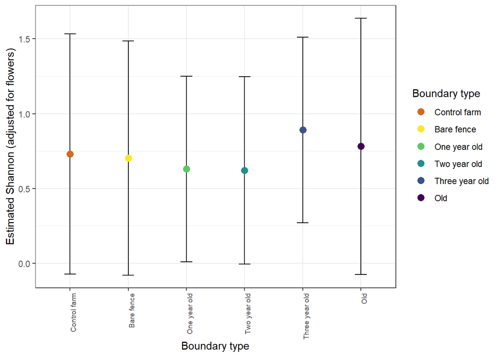

```r
cld_rich$Boundary_descriptor <- factor(cld_rich$Boundary_descriptor,levels=c('Control farm','Bare fence','One year old','Two year old','Three year old','Old'),ordered = T)

ggplot(cld_rich, aes(x = Boundary_descriptor, y = emmean)) +
#  facet_wrap(~Season)+
  theme_bw()+
  geom_errorbar(aes(ymin = lower.CL, ymax = upper.CL), width = 0.2) +
  geom_point(size = 3,aes(colour=Boundary_descriptor)) +
  scale_colour_manual(values=col_bound)+
# not sure if groupings will make sense with facet wrap
#  geom_text(aes(label = .group, y = asymp.UCL + 0.2), vjust = 0, size = 5) +
  labs(y = "Estimated Shannon (adjusted for flowers)", x = "Boundary type", colour='Boundary type') +
  theme(axis.text.x = element_text(angle = 90,size=7,hjust=1))
```

## Using renyi profiles

Tracking the difference between the two communities using a renyi profile method. Dont think we can use this in the paper as I cant get season, date or farm in there for the nesting. But thought it was interesting.

The Renyi diversity profile at scale 0 reflects species richness, at scale 1 the Shannon index, at scale 2 the Simpson index and at scale Inf the Berger-Parker index (the dominance of the most abundant species):

If the profiles cross over then it may not be possible to compare diversity. I find this interesting as its the old samples that cross over. The 3 year olds don’t. This follows the above shannon/simpson analysis that shows evenness is highest in the 3-year old samples. We cant actually include this in the final paper as its not taking into account flower number/farm/date sampled like the models above are. But I wanted to get your thoughts on it as I havent seen data like this. Though the fly one was similar when simpson was so high for apple as there was basically no diversity at apple so it was perfectly even. We should probably include the accumulation plot in the supplementary though (along with the innext plots).

Im thinking that this suggests a lot more rare species are coming into the plantings compared to the bare fence. So the evenness becomes quite lower compared to the bare fence/control plantings. Which feeds into that science paper we discussed the other day about bee species rather than bee number being important.

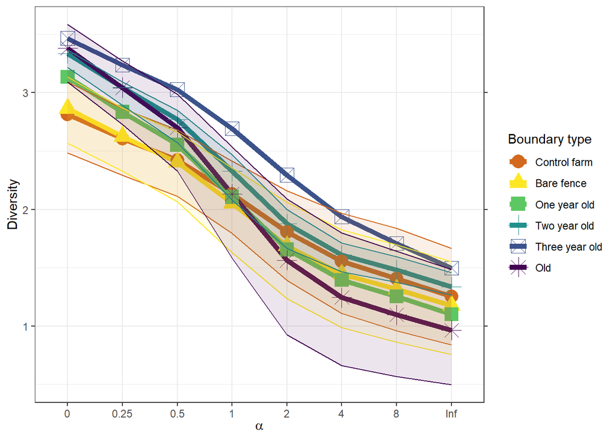

```r
meta_data$Boundary_descriptorf<-factor(meta_data$Boundary_descriptor, levels = c('Control farm','Bare fence',"One year old","Two year old","Three year old","Old"))
meta_data_bior<-as.data.frame(meta_data)
Renyi.1<-renyicomp(counts_wide,y=meta_data_bior,factor='Boundary_descriptorf',
  scales=c(0, 0.25, 0.5, 1, 2, 4, 8, Inf), permutations=1000, plotit=F)
renyi.long1 <- renyicomp.long(Renyi.1, label.freq=1)
renyi.long1_dataframe<-data.frame(renyi.long1$labelit,renyi.long1$Scales,renyi.long1$Obs,renyi.long1$Diversity,renyi.long1$UPR,renyi.long1$LWR,renyi.long1$Grouping)
renyi.long1_dataframe$Boundary_descriptor<-factor(renyi.long1_dataframe$renyi.long1.Grouping, levels = c('Control farm','Bare fence',"One year old","Two year old","Three year old","Old"))

pl_renyi_across <- ggplot(data=renyi.long1_dataframe, aes(x=renyi.long1.Scales, y=renyi.long1.Diversity, ymax=renyi.long1.UPR, ymin=renyi.long1.LWR)) +
    scale_x_discrete() +
    scale_y_continuous(sec.axis = dup_axis(labels=NULL, name=NULL)) +
    geom_line(data=renyi.long1_dataframe,
              aes(x=renyi.long1.Obs, colour=Boundary_descriptor),
              linewidth=2) +
    geom_point(data=subset(renyi.long1_dataframe, renyi.long1.labelit==TRUE),
        aes(colour=Boundary_descriptor, shape=Boundary_descriptor),
        size=5) +
    geom_ribbon(data=renyi.long1_dataframe,
                aes(x=renyi.long1.Obs, colour=Boundary_descriptor, fill=after_scale(alpha(colour, 0.1))),
                show.legend=FALSE) +
     scale_colour_manual(values=col_bound)+
    theme_bw() +
    #scale_colour_npg() +
    labs(x=expression(alpha), y = "Diversity", colour = "Boundary type", shape = "Boundary type")
pl_renyi_across
```

```r
#not great but that is conflated with the effect of season so break it up by season:
meta_data_bior_season<-meta_data_bior %>% filter(Season=='2023/24')
meta_data_bior_season %>% select(Boundary_descriptor) %>% group_by(Boundary_descriptor) %>% summarise(count = n())
```

```
## # A tibble: 6 × 2
##   Boundary_descriptor count
##   <chr>               <int>
## 1 Bare fence              7
## 2 Control farm           11
## 3 Old                    13
## 4 One year old            1
## 5 Three year old          7
## 6 Two year old            1
```

```r
counts_wide_filt <- counts_wide[rownames(counts_wide) %in% meta_data_bior_season$unique_sample, ]
counts_wide_filt <- counts_wide_filt[,colSums(counts_wide_filt) > 0]
Renyi.1<-renyicomp(counts_wide_filt,y=meta_data_bior_season,factor='Boundary_descriptorf',
  scales=c(0, 0.25, 0.5, 1, 2, 4, 8, Inf), permutations=1000, plotit=F)
```

```
## Set of permutations < 'minperm'. Generating entire set.
## Set of permutations < 'minperm'. Generating entire set.
```

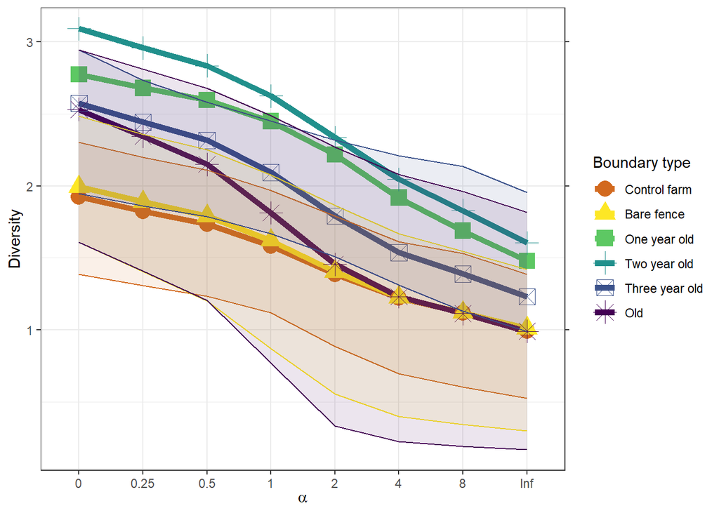

```r
renyi.long1 <- renyicomp.long(Renyi.1, label.freq=1)
renyi.long1_dataframe<-data.frame(renyi.long1$labelit,renyi.long1$Scales,renyi.long1$Obs,renyi.long1$Diversity,renyi.long1$UPR,renyi.long1$LWR,renyi.long1$Grouping)
renyi.long1_dataframe$Boundary_descriptor<-factor(renyi.long1_dataframe$renyi.long1.Grouping, levels = c('Control farm','Bare fence',"One year old","Two year old","Three year old","Old"))

pl_renyi_across <- ggplot(data=renyi.long1_dataframe, aes(x=renyi.long1.Scales, y=renyi.long1.Diversity, ymax=renyi.long1.UPR, ymin=renyi.long1.LWR)) +
    scale_x_discrete() +
    scale_y_continuous(sec.axis = dup_axis(labels=NULL, name=NULL)) +
    geom_line(data=renyi.long1_dataframe,
              aes(x=renyi.long1.Obs, colour=Boundary_descriptor),
              linewidth=2) +
    geom_point(data=subset(renyi.long1_dataframe, renyi.long1.labelit==TRUE),
        aes(colour=Boundary_descriptor, shape=Boundary_descriptor),
        size=5) +
    geom_ribbon(data=renyi.long1_dataframe,
                aes(x=renyi.long1.Obs, colour=Boundary_descriptor, fill=after_scale(alpha(colour, 0.1))),
                show.legend=FALSE) +
     scale_colour_manual(values=col_bound)+
    theme_bw() +
    #scale_colour_npg() +
    labs(x=expression(alpha), y = "Diversity", colour = "Boundary type", shape = "Boundary type")
pl_renyi_across
```

```r
#2022/23
meta_data_bior_season<-meta_data_bior %>% filter(Season=='2022/23')
meta_data_bior_season %>% select(Boundary_descriptor) %>% group_by(Boundary_descriptor) %>% summarise(count = n())
```

```
## # A tibble: 4 × 2
##   Boundary_descriptor count
##   <chr>               <int>
## 1 Bare fence             10
## 2 Control farm            9
## 3 Old                    12
## 4 Two year old            7
```

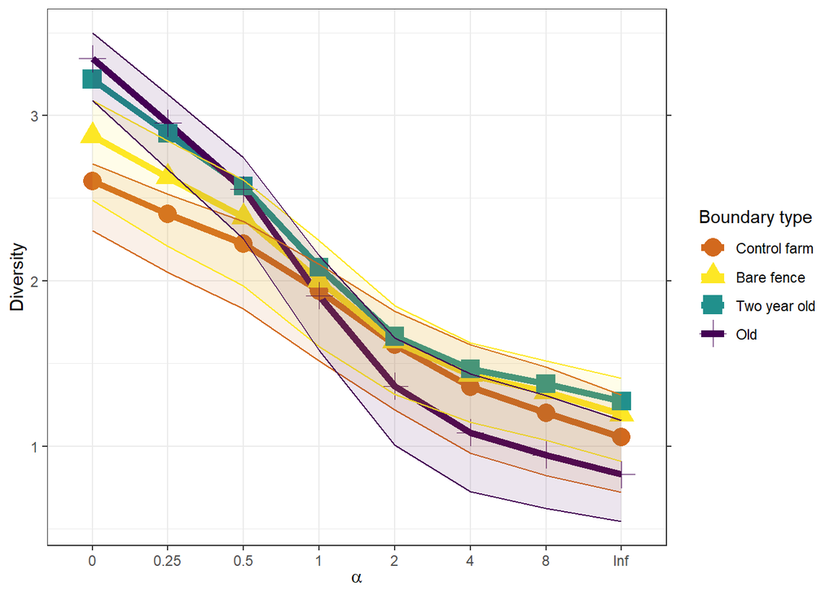

```r
meta_data_bior_season$Boundary_descriptorf<-factor(meta_data_bior_season$Boundary_descriptor, levels = c('Control farm','Bare fence',"Two year old","Old"))
counts_wide_filt <- counts_wide[rownames(counts_wide) %in% meta_data_bior_season$unique_sample, ]
counts_wide_filt <- counts_wide_filt[,colSums(counts_wide_filt) > 0]
Renyi.1<-renyicomp(counts_wide_filt,y=meta_data_bior_season,factor='Boundary_descriptorf',
  scales=c(0, 0.25, 0.5, 1, 2, 4, 8, Inf), permutations=1000, plotit=F)
renyi.long1 <- renyicomp.long(Renyi.1, label.freq=1)
renyi.long1_dataframe<-data.frame(renyi.long1$labelit,renyi.long1$Scales,renyi.long1$Obs,renyi.long1$Diversity,renyi.long1$UPR,renyi.long1$LWR,renyi.long1$Grouping)
renyi.long1_dataframe$Boundary_descriptor<-factor(renyi.long1_dataframe$renyi.long1.Grouping, levels = c('Control farm','Bare fence',"Two year old","Old"))
col_bound_cut<-c('chocolate','#FDE725FF',"#21908CFF","#440154FF")


pl_renyi_across <- ggplot(data=renyi.long1_dataframe, aes(x=renyi.long1.Scales, y=renyi.long1.Diversity, ymax=renyi.long1.UPR, ymin=renyi.long1.LWR)) +
    scale_x_discrete() +
    scale_y_continuous(sec.axis = dup_axis(labels=NULL, name=NULL)) +
    geom_line(data=renyi.long1_dataframe,
              aes(x=renyi.long1.Obs, colour=Boundary_descriptor),
              linewidth=2) +
    geom_point(data=subset(renyi.long1_dataframe, renyi.long1.labelit==TRUE),
        aes(colour=Boundary_descriptor, shape=Boundary_descriptor),
        size=5) +
    geom_ribbon(data=renyi.long1_dataframe,
                aes(x=renyi.long1.Obs, colour=Boundary_descriptor, fill=after_scale(alpha(colour, 0.1))),
                show.legend=FALSE) +
     scale_colour_manual(values=col_bound_cut)+
    theme_bw() +
    #scale_colour_npg() +
    labs(x=expression(alpha), y = "Diversity", colour = "Boundary type", shape = "Boundary type")
pl_renyi_across
```

```r
#2021/22
meta_data_bior_season<-meta_data_bior %>% filter(Season=='2021/22')
meta_data_bior_season %>% select(Boundary_descriptor) %>% group_by(Boundary_descriptor) %>% summarise(count = n())
```

```
## # A tibble: 4 × 2
##   Boundary_descriptor count
##   <chr>               <int>
## 1 Bare fence             10
## 2 Control farm            9
## 3 Old                    12
## 4 One year old            6
```

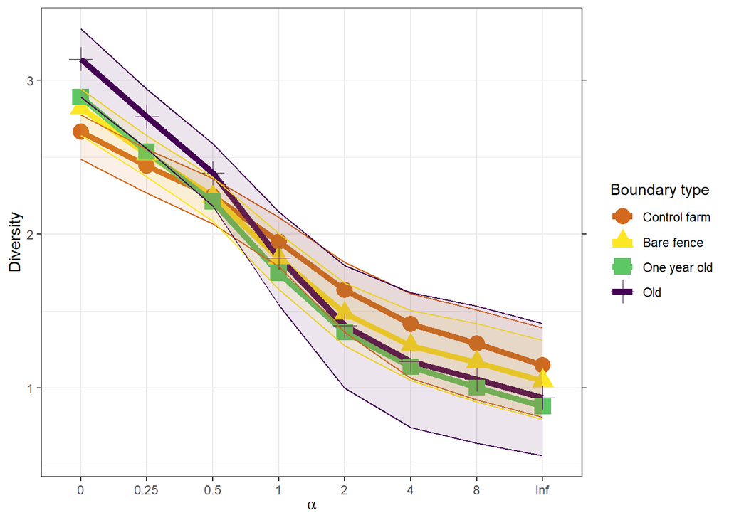

```r
meta_data_bior_season$Boundary_descriptorf<-factor(meta_data_bior_season$Boundary_descriptor, levels = c('Control farm','Bare fence',"One year old","Old"))
counts_wide_filt <- counts_wide[rownames(counts_wide) %in% meta_data_bior_season$unique_sample, ]
counts_wide_filt <- counts_wide_filt[,colSums(counts_wide_filt) > 0]
Renyi.1<-renyicomp(counts_wide_filt,y=meta_data_bior_season,factor='Boundary_descriptorf',
  scales=c(0, 0.25, 0.5, 1, 2, 4, 8, Inf), permutations=1000, plotit=F)
renyi.long1 <- renyicomp.long(Renyi.1, label.freq=1)
renyi.long1_dataframe<-data.frame(renyi.long1$labelit,renyi.long1$Scales,renyi.long1$Obs,renyi.long1$Diversity,renyi.long1$UPR,renyi.long1$LWR,renyi.long1$Grouping)
renyi.long1_dataframe$Boundary_descriptor<-factor(renyi.long1_dataframe$renyi.long1.Grouping, levels = c('Control farm','Bare fence',"One year old","Old"))
col_bound_cut<-c('chocolate','#FDE725FF',"#5DC863FF","#440154FF")

pl_renyi_across <- ggplot(data=renyi.long1_dataframe, aes(x=renyi.long1.Scales, y=renyi.long1.Diversity, ymax=renyi.long1.UPR, ymin=renyi.long1.LWR)) +
    scale_x_discrete() +
    scale_y_continuous(sec.axis = dup_axis(labels=NULL, name=NULL)) +
    geom_line(data=renyi.long1_dataframe,
              aes(x=renyi.long1.Obs, colour=Boundary_descriptor),
              linewidth=2) +
    geom_point(data=subset(renyi.long1_dataframe, renyi.long1.labelit==TRUE),
        aes(colour=Boundary_descriptor, shape=Boundary_descriptor),
        size=5) +
    geom_ribbon(data=renyi.long1_dataframe,
                aes(x=renyi.long1.Obs, colour=Boundary_descriptor, fill=after_scale(alpha(colour, 0.1))),
                show.legend=FALSE) +
     scale_colour_manual(values=col_bound_cut)+
    theme_bw() +
    #scale_colour_npg() +
    labs(x=expression(alpha), y = "Diversity", colour = "Boundary type", shape = "Boundary type")
pl_renyi_across
```

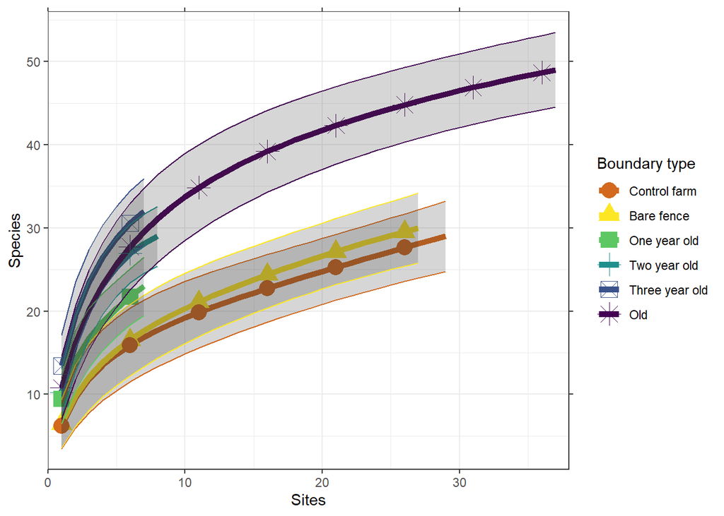

```r
#hmmm pattern holds across seasons, I thought maybe that it would be one season throwing everyone out

#just having a look at the accum results:
Accum.1 <- accumcomp(counts_wide,y=meta_data_bior,factor='Boundary_descriptorf',
    method='exact', conditioned=FALSE, plotit=FALSE)
accum.long1 <- accumcomp.long(Accum.1, ci=NA, label.freq=5)
accum.long1_dataframe<-data.frame(accum.long1$Grouping,accum.long1$Obs,accum.long1$Sites,accum.long1$Richness,accum.long1$LWR,accum.long1$UPR,accum.long1$labelit)
accum.long1_dataframe$Boundary_descriptor<-factor(accum.long1_dataframe$accum.long1.Grouping, levels = c('Control farm','Bare fence',"One year old","Two year old","Three year old","Old"))


plotgg1 <- ggplot(data=accum.long1_dataframe, aes(x = accum.long1.Sites, y = accum.long1.Richness, ymax = accum.long1.UPR, ymin = accum.long1.LWR)) +
    scale_x_continuous(expand=c(0, 1), sec.axis = dup_axis(labels=NULL, name=NULL)) +
    scale_y_continuous(sec.axis = dup_axis(labels=NULL, name=NULL)) +
    geom_line(aes(colour=Boundary_descriptor), linewidth=2) +
    geom_point(data=subset(accum.long1_dataframe, accum.long1.labelit==TRUE),
               aes(colour=Boundary_descriptor, shape=Boundary_descriptor), size=5) +
    geom_ribbon(aes(colour=Boundary_descriptor), alpha=0.2, show.legend=FALSE) +
     scale_colour_manual(values=col_bound)+
    theme_bw() +
    labs(x = "Sites", y = "Species", colour = "Boundary type", shape = "Boundary type")
plotgg1
```

```r
#
```

## Beta Diversity

Beta diversity analysis Normally I would do beta diversity through adonis2 and MDS but Im not sure this will work due to the strange structure. Adonis2 works with nesting via a strata factor that blocks permutations to within groups however if you add both Date and Farm there is only one permutation option (each sample is in a unique block).

This analysis is important but Im finding it the most difficult as it makes a large difference how I structure the data. In the other diversity tests, it really doesnt make much difference to the overal result but here it does.

```
## Permutation test for adonis under reduced model
## Permutation: free
## Number of permutations: 999
##
## adonis2(formula = counts_wide ~ Boundary_descriptor, data = meta_data)
##           Df SumOfSqs      R2      F Pr(>F)
## Model      5   2.9863 0.10375 2.5235  0.001 ***
## Residual 109  25.7980 0.89625
## Total    114  28.7843 1.00000
## ---
## Signif. codes:  0 '***' 0.001 '**' 0.01 '*' 0.05 '.' 0.1 ' ' 1
```

```
## Permutation test for adonis under reduced model
## Permutation: free
## Number of permutations: 999
##
## adonis2(formula = counts_wide ~ Season, data = meta_data)
##           Df SumOfSqs      R2      F Pr(>F)
## Model      2   2.1368 0.07424 4.4906  0.001 ***
## Residual 112  26.6475 0.92576
## Total    114  28.7843 1.00000
## ---
## Signif. codes:  0 '***' 0.001 '**' 0.01 '*' 0.05 '.' 0.1 ' ' 1
```

```
## Permutation test for adonis under reduced model
## Permutation: free
## Number of permutations: 999
##
## adonis2(formula = counts_wide ~ `Farm type`, data = meta_data)
##           Df SumOfSqs      R2      F Pr(>F)
## Model      1   0.7371 0.02561 2.9699  0.005 **
## Residual 113  28.0472 0.97439
## Total    114  28.7843 1.00000
## ---
## Signif. codes:  0 '***' 0.001 '**' 0.01 '*' 0.05 '.' 0.1 ' ' 1
```

```
## Permutation test for adonis under reduced model
## Permutation: free
## Number of permutations: 999
##
## adonis2(formula = counts_wide ~ Boundary_descriptor + `Flower count`, data = meta_data)
##           Df SumOfSqs      R2      F Pr(>F)
## Model      6   3.6673 0.12741 2.6282  0.001 ***
## Residual 108  25.1170 0.87259
## Total    114  28.7843 1.00000
## ---
## Signif. codes:  0 '***' 0.001 '**' 0.01 '*' 0.05 '.' 0.1 ' ' 1
```

```
## Permutation test for adonis under reduced model
## Permutation: free
## Number of permutations: 999
##
## adonis2(formula = counts_wide ~ Boundary_descriptor + `Flower count` + Season, data = meta_data)
##           Df SumOfSqs     R2      F Pr(>F)
## Model      8    5.659 0.1966 3.2424  0.001 ***
## Residual 106   23.125 0.8034
## Total    114   28.784 1.0000
## ---
## Signif. codes:  0 '***' 0.001 '**' 0.01 '*' 0.05 '.' 0.1 ' ' 1
```

```
## Permutation test for adonis under reduced model
## Blocks:  strata
## Permutation: free
## Number of permutations: 999
##
## adonis2(formula = counts_wide ~ Boundary_descriptor + `Flower count`, data = meta_data, strata = meta_data$Season)
##           Df SumOfSqs      R2      F Pr(>F)
## Model      6   3.6673 0.12741 2.6282  0.001 ***
## Residual 108  25.1170 0.87259
## Total    114  28.7843 1.00000
## ---
## Signif. codes:  0 '***' 0.001 '**' 0.01 '*' 0.05 '.' 0.1 ' ' 1
```

```
## $parent_call
## [1] "counts_wide ~ Boundary_descriptor + `Flower count` , strata = Season , permutations 999"
##
## $`Control farm_vs_One year old`
##          Df SumOfSqs      R2      F Pr(>F)
## Model     2   1.0454 0.10636 1.9638  0.038 *
## Residual 33   8.7838 0.89364
## Total    35   9.8292 1.00000
## ---
## Signif. codes:  0 '***' 0.001 '**' 0.01 '*' 0.05 '.' 0.1 ' ' 1
##
## $`Control farm_vs_Two year old`
##          Df SumOfSqs      R2     F Pr(>F)
## Model     2   0.8740 0.08803 1.641  0.034 *
## Residual 34   9.0537 0.91197
## Total    36   9.9276 1.00000
## ---
## Signif. codes:  0 '***' 0.001 '**' 0.01 '*' 0.05 '.' 0.1 ' ' 1
##
## $`Control farm_vs_Three year old`
##          Df SumOfSqs      R2      F Pr(>F)
## Model     2   0.8502 0.08939 1.6197  0.086 .
## Residual 33   8.6612 0.91061
## Total    35   9.5114 1.00000
## ---
## Signif. codes:  0 '***' 0.001 '**' 0.01 '*' 0.05 '.' 0.1 ' ' 1
##
## $`Control farm_vs_Old`
##          Df SumOfSqs      R2      F Pr(>F)
## Model     2   1.7862 0.11036 3.9077  0.001 ***
## Residual 63  14.3983 0.88964
## Total    65  16.1845 1.00000
## ---
## Signif. codes:  0 '***' 0.001 '**' 0.01 '*' 0.05 '.' 0.1 ' ' 1
##
## $`Control farm_vs_Bare fence`
##          Df SumOfSqs      R2      F Pr(>F)
## Model     2   0.6315 0.04384 1.2149  0.254
## Residual 53  13.7734 0.95616
## Total    55  14.4048 1.00000
```

[output cut: 60 more lines]

```
##          Df SumOfSqs      R2      F Pr(>F)
## Model     2   0.9082 0.10835 1.8835  0.124
## Residual 31   7.4744 0.89165
## Total    33   8.3826 1.00000
##
## $`Old_vs_Bare fence`
##          Df SumOfSqs      R2      F Pr(>F)
## Model     2   1.5673 0.10603 3.6173  0.001 ***
## Residual 61  13.2151 0.89397
## Total    63  14.7824 1.00000
## ---
## Signif. codes:  0 '***' 0.001 '**' 0.01 '*' 0.05 '.' 0.1 ' ' 1
##
## attr(,"class")
## [1] "pwadstrata" "list"
```

```
## Permutation test for adonis under reduced model
## Blocks:  strata
## Permutation: free
## Number of permutations: 999
##
## adonis2(formula = counts_wide ~ Farmtypef + `Flower count`, data = meta_data_bior, strata = meta_data_bior$Season)
##           Df SumOfSqs      R2      F Pr(>F)
## Model      2    1.370 0.04759 2.7985  0.001 ***
## Residual 112   27.414 0.95241
## Total    114   28.784 1.00000
## ---
## Signif. codes:  0 '***' 0.001 '**' 0.01 '*' 0.05 '.' 0.1 ' ' 1
```

```
## $parent_call
## [1] "counts_wide ~ Farmtypef + `Flower count` , strata = Season , permutations 999"
##
## $Arable_vs_Dairy
##           Df SumOfSqs      R2      F Pr(>F)
## Model      2    1.370 0.04759 2.7985  0.001 ***
## Residual 112   27.414 0.95241
## Total    114   28.784 1.00000
## ---
## Signif. codes:  0 '***' 0.001 '**' 0.01 '*' 0.05 '.' 0.1 ' ' 1
##
## attr(,"class")
## [1] "pwadstrata" "list"
```

```
## Permutation test for adonis under reduced model
## Blocks:  strata
## Permutation: free
## Number of permutations: 999
##
## adonis2(formula = counts_wide ~ Boundary_descriptor + `Flower count`, data = meta_data, strata = meta_data$Site)
##           Df SumOfSqs      R2      F Pr(>F)
## Model      6   3.6673 0.12741 2.6282  0.008 **
## Residual 108  25.1170 0.87259
## Total    114  28.7843 1.00000
## ---
## Signif. codes:  0 '***' 0.001 '**' 0.01 '*' 0.05 '.' 0.1 ' ' 1
```

```
## 'nperm' >= set of all permutations: complete enumeration.
```

```
## Set of permutations < 'minperm'. Generating entire set.
```

```
## 'nperm' >= set of all permutations: complete enumeration.
```

```
## Set of permutations < 'minperm'. Generating entire set.
```

```
## 'nperm' >= set of all permutations: complete enumeration.
```

```
## Set of permutations < 'minperm'. Generating entire set.
```

```
## Permutation test for adonis under reduced model
## Blocks:  strata
## Permutation: free
## Number of permutations: 999
##
## adonis2(formula = counts_wide ~ Boundary_descriptor + `Flower count`, data = meta_data, strata = meta_data$Date)
##           Df SumOfSqs      R2      F Pr(>F)
## Model      6   3.6673 0.12741 2.6282  0.001 ***
## Residual 108  25.1170 0.87259
## Total    114  28.7843 1.00000
## ---
## Signif. codes:  0 '***' 0.001 '**' 0.01 '*' 0.05 '.' 0.1 ' ' 1
```

```
## 'nperm' >= set of all permutations: complete enumeration.
## Set of permutations < 'minperm'. Generating entire set.
```

```
## 'nperm' >= set of all permutations: complete enumeration.
```

```
## Set of permutations < 'minperm'. Generating entire set.
```

```
## 'nperm' >= set of all permutations: complete enumeration.
```

```
## Set of permutations < 'minperm'. Generating entire set.
## Set of permutations < 'minperm'. Generating entire set.
```

```
## 'nperm' >= set of all permutations: complete enumeration.
```

```
## Set of permutations < 'minperm'. Generating entire set.
```

```
## Permutation test for adonis under reduced model
## Blocks:  strata
## Permutation: free
## Number of permutations: 0
##
## adonis2(formula = counts_wide ~ Boundary_descriptor + `Flower count`, data = meta_data, strata = meta_data$site_day)
##           Df SumOfSqs      R2      F Pr(>F)
## Model      6   3.6673 0.12741 2.6282      1
## Residual 108  25.1170 0.87259
## Total    114  28.7843 1.00000
```

```
## 'nperm' >= set of all permutations: complete enumeration.
## Set of permutations < 'minperm'. Generating entire set.
```

```
## Permutation test for adonis under reduced model
## Blocks:  strata
## Permutation: free
## Number of permutations: 0
##
## adonis2(formula = counts_wide ~ Boundary_descriptor + `Flower count`, data = meta_data, strata = meta_data$site_season)
##           Df SumOfSqs      R2      F Pr(>F)
## Model      6   3.6673 0.12741 2.6282      1
## Residual 108  25.1170 0.87259
## Total    114  28.7843 1.00000
```

```
## Permutation test for adonis under reduced model
## Blocks:  strata
## Permutation: free
## Number of permutations: 999
##
## adonis2(formula = counts_wide ~ Boundary_descriptor + `Flower count`, data = meta_data, strata = meta_data$date_season)
##           Df SumOfSqs      R2      F Pr(>F)
## Model      6   3.6673 0.12741 2.6282  0.001 ***
## Residual 108  25.1170 0.87259
## Total    114  28.7843 1.00000
## ---
## Signif. codes:  0 '***' 0.001 '**' 0.01 '*' 0.05 '.' 0.1 ' ' 1
```

```
## $parent_call
## [1] "counts_wide ~ Boundary_descriptor , strata = 3 , permutations 999"
##
## $`Control farm_vs_One year old`
##          Df SumOfSqs      R2      F Pr(>F)
## Model     1   0.4640 0.04721 1.6847  0.231
## Residual 34   9.3652 0.95279
## Total    35   9.8292 1.00000
##
## $`Control farm_vs_Two year old`
##          Df SumOfSqs      R2      F Pr(>F)
## Model     1   0.5242 0.05281 1.9512  0.035 *
## Residual 35   9.4034 0.94719
## Total    36   9.9276 1.00000
## ---
## Signif. codes:  0 '***' 0.001 '**' 0.01 '*' 0.05 '.' 0.1 ' ' 1
##
## $`Control farm_vs_Three year old`
##          Df SumOfSqs      R2      F Pr(>F)
## Model     1   0.5398 0.05675 2.0455  0.053 .
## Residual 34   8.9717 0.94325
## Total    35   9.5114 1.00000
## ---
## Signif. codes:  0 '***' 0.001 '**' 0.01 '*' 0.05 '.' 0.1 ' ' 1
##
## $`Control farm_vs_Old`
##          Df SumOfSqs     R2      F Pr(>F)
## Model     1   1.4129 0.0873 6.1214  0.001 ***
## Residual 64  14.7716 0.9127
## Total    65  16.1845 1.0000
## ---
## Signif. codes:  0 '***' 0.001 '**' 0.01 '*' 0.05 '.' 0.1 ' ' 1
##
## $`Control farm_vs_Bare fence`
##          Df SumOfSqs      R2      F Pr(>F)
## Model     1   0.1315 0.00913 0.4976  0.871
## Residual 54  14.2733 0.99087
## Total    55  14.4048 1.00000
##
## $`One year old_vs_Two year old`
```

[output cut: 52 more lines]

```
## Residual 32   7.7514 0.9247
## Total    33   8.3826 1.0000
## ---
## Signif. codes:  0 '***' 0.001 '**' 0.01 '*' 0.05 '.' 0.1 ' ' 1
##
## $`Old_vs_Bare fence`
##          Df SumOfSqs      R2      F Pr(>F)
## Model     1   1.2311 0.08328 5.6325  0.001 ***
## Residual 62  13.5513 0.91672
## Total    63  14.7824 1.00000
## ---
## Signif. codes:  0 '***' 0.001 '**' 0.01 '*' 0.05 '.' 0.1 ' ' 1
##
## attr(,"class")
## [1] "pwadstrata" "list"
```

```
## Permutation test for adonis under reduced model
## Blocks:  strata
## Permutation: free
## Number of permutations: 999
##
## adonis2(formula = counts_wide ~ Boundary_descriptor + Season + `Flower count`, data = meta_data, strata = meta_data$Site)
##           Df SumOfSqs     R2      F Pr(>F)
## Model      8    5.659 0.1966 3.2424  0.001 ***
## Residual 106   23.125 0.8034
## Total    114   28.784 1.0000
## ---
## Signif. codes:  0 '***' 0.001 '**' 0.01 '*' 0.05 '.' 0.1 ' ' 1
```

```
## 'nperm' >= set of all permutations: complete enumeration.
## Set of permutations < 'minperm'. Generating entire set.
```

```
## 'nperm' >= set of all permutations: complete enumeration.
```

```
## Set of permutations < 'minperm'. Generating entire set.
```

```
## 'nperm' >= set of all permutations: complete enumeration.
```

```
## Set of permutations < 'minperm'. Generating entire set.
```

```
## Permutation test for adonis under reduced model
## Blocks:  strata
## Permutation: free
## Number of permutations: 999
##
## adonis2(formula = counts_wide ~ Boundary_descriptor + Season + `Flower count`, data = meta_data, strata = meta_data$Date)
##           Df SumOfSqs     R2      F Pr(>F)
## Model      8    5.659 0.1966 3.2424  0.001 ***
## Residual 106   23.125 0.8034
## Total    114   28.784 1.0000
## ---
## Signif. codes:  0 '***' 0.001 '**' 0.01 '*' 0.05 '.' 0.1 ' ' 1
```

```
## 'nperm' >= set of all permutations: complete enumeration.
## Set of permutations < 'minperm'. Generating entire set.
```

```
## 'nperm' >= set of all permutations: complete enumeration.
```

```
## Set of permutations < 'minperm'. Generating entire set.
```

```
## 'nperm' >= set of all permutations: complete enumeration.
```

```
## Set of permutations < 'minperm'. Generating entire set.
## Set of permutations < 'minperm'. Generating entire set.
```

## NMDS

NMDS plot

```r
#NMDS is struggling to find a repeated solution. I think this is due to the rare species
#https://stats.stackexchange.com/questions/649643/best-solution-was-not-repeated-no-reliable-result-for-metamds
pk_NMDS <- metaMDS(counts_wide,trymax=200)
```

```
## Square root transformation
## Wisconsin double standardization
## *** Best solution repeated 1 times
```

```r
pk_NMDS
```

```
##
## Call:
## metaMDS(comm = counts_wide, trymax = 200)
##
## global Multidimensional Scaling using monoMDS
##
## Data:     wisconsin(sqrt(counts_wide))
## Distance: bray
##
## Dimensions: 2
## Stress:     0.2624369
## Stress type 1, weak ties
## Best solution was repeated 1 time in 77 tries
## The best solution was from try 77 (random start)
## Scaling: centring, PC rotation, halfchange scaling
## Species: expanded scores based on 'wisconsin(sqrt(counts_wide))'
```

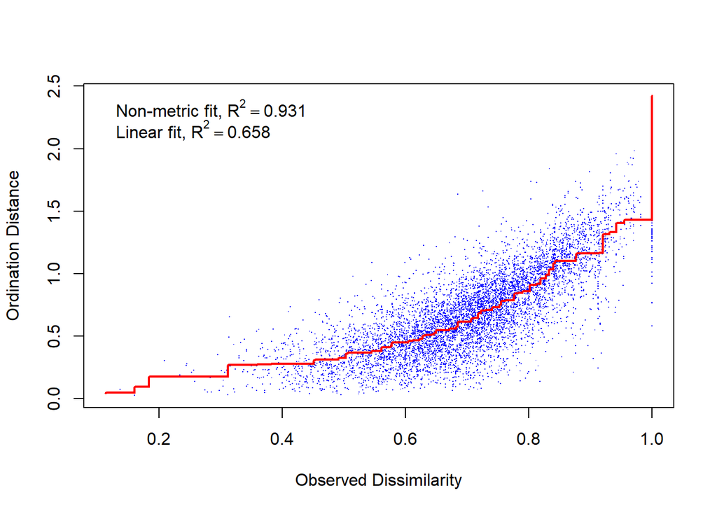

```r
#stress is a little high (ideally <0.2)

stressplot(pk_NMDS)
```

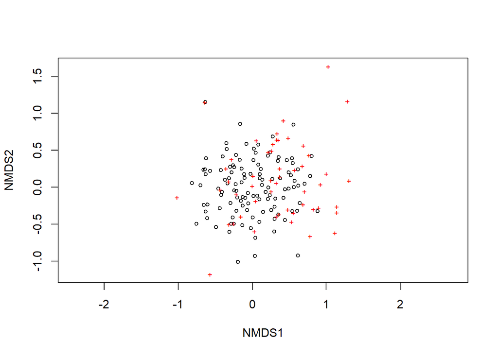

```r
plot(pk_NMDS)
```

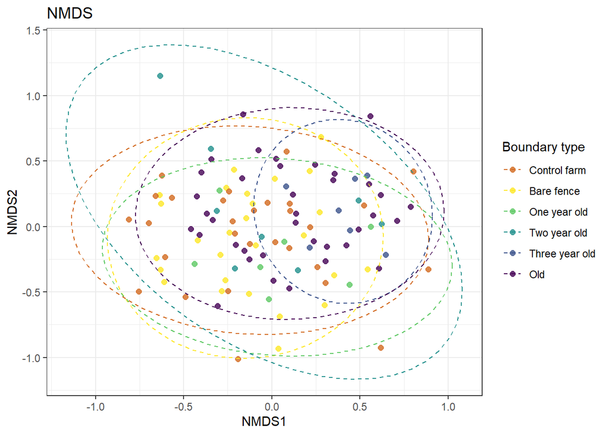

```r
plot_df <- scores(pk_NMDS, display = "sites") %>%
  as.data.frame() %>%
  rownames_to_column("site") %>%
  full_join(meta_data, by = c("site" = "unique_sample"))

plot_df$Boundary_descriptor <- factor(plot_df$Boundary_descriptor,levels=c('Control farm','Bare fence','One year old','Two year old','Three year old','Old'),ordered = T)


plot_nmds <- ggplot(plot_df, aes(x = NMDS1, y = NMDS2, color = Boundary_descriptor)) +
  geom_point(size = 2, alpha = 0.8) +
  stat_ellipse(linetype = 2, linewidth = 0.5) +
  theme_bw()+
    scale_colour_manual(values=col_bound)+
  labs(title = "NMDS",
       colour = "Boundary type")
plot_nmds
```

## NMDS by season

NMDS plot by season - doesnt show much, just kept it here to show that it doesnt make much difference, just thought originally that maybe season was interfering with the structure of the plot.

```r
#splitting by season
#seasons are
#2021/22
#2022/23
#2023/24

counts_wide_202122<-counts_wide[grep("2021/22", row.names(counts_wide)),]
counts_wide_202223<-counts_wide[grep("2022/23", row.names(counts_wide)),]
counts_wide_202324<-counts_wide[grep("2023/24", row.names(counts_wide)),]

#season 2021-2022
pk_NMDS <- metaMDS(counts_wide_202122,trymax=200)
```

```
## Square root transformation
## Wisconsin double standardization
## *** Best solution was not repeated -- monoMDS stopping criteria:
##      4: no. of iterations >= maxit
##    196: stress ratio > sratmax
```

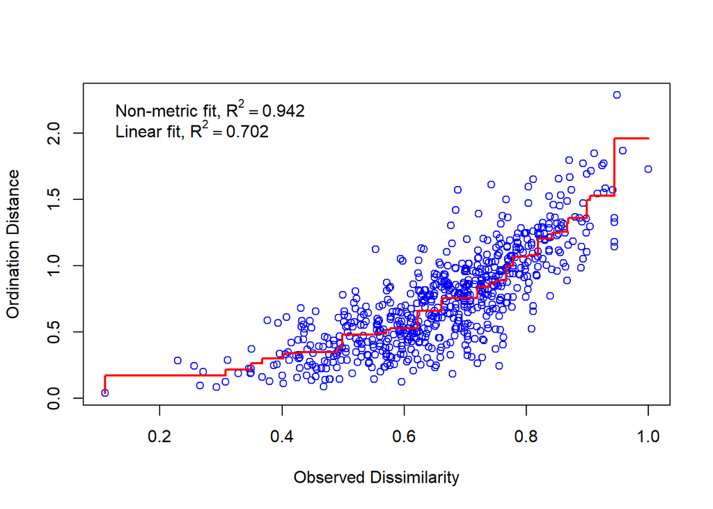

```r
stressplot(pk_NMDS)
```

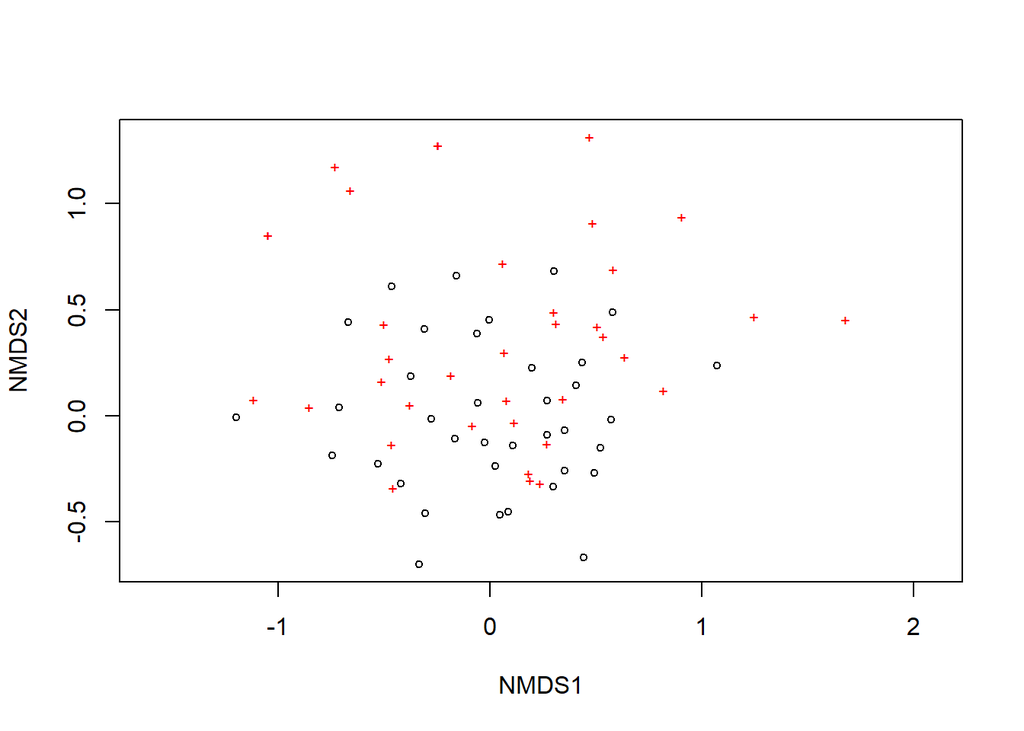

```r
plot(pk_NMDS)
```

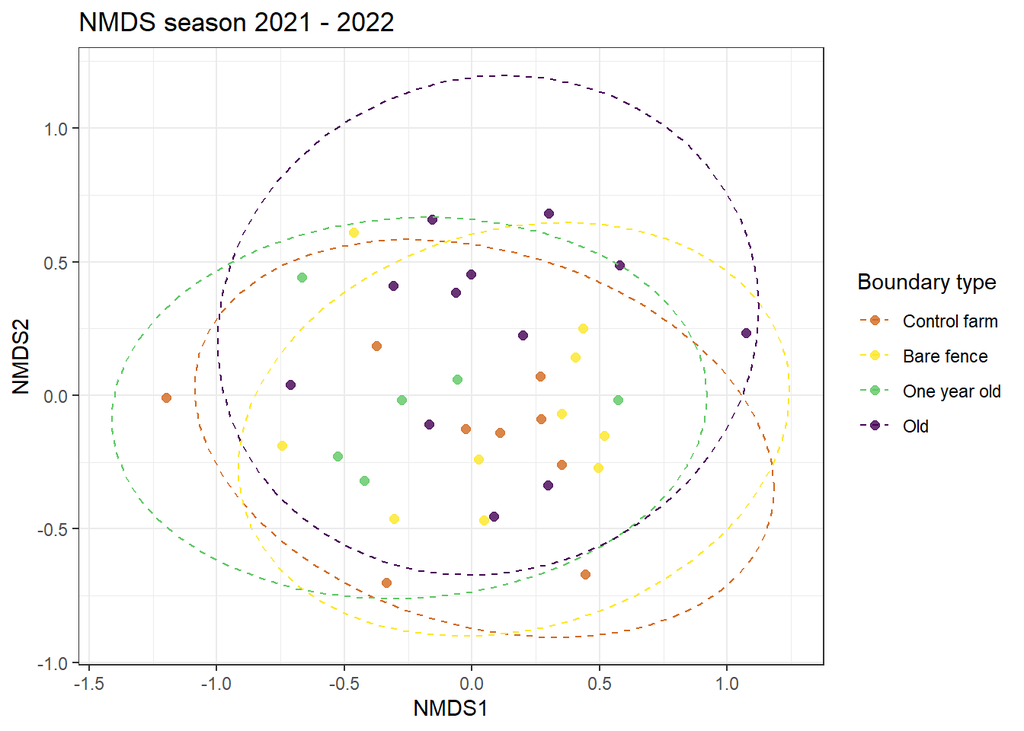

```r
plot_df <- scores(pk_NMDS, display = "sites") %>%
  as.data.frame() %>%
  rownames_to_column("site") %>%
  left_join(meta_data, by = c("site" = "unique_sample"))

plot_df$Boundary_descriptor <- factor(plot_df$Boundary_descriptor,levels=c('Control farm','Bare fence','One year old','Two year old','Three year old','Old'),ordered = T)

col_bound2<-c("chocolate", "#FDE725FF", "#5DC863FF", "#440154FF")

plot_nmds <- ggplot(plot_df, aes(x = NMDS1, y = NMDS2, color = Boundary_descriptor)) +
  geom_point(size = 2, alpha = 0.8) +
  stat_ellipse(linetype = 2, linewidth = 0.5) +
  theme_bw()+
    scale_colour_manual(values=col_bound2)+
  labs(title = "NMDS season 2021 - 2022",
       colour = "Boundary type")
plot_nmds
```